# 34_Google_Q_A_Dec082020

```python
!ls -R
```

```
.:
sample_data

./sample_data:
anscombe.json		      mnist_test.csv
california_housing_test.csv   mnist_train_small.csv
california_housing_train.csv  README.md
```

```python
from google.colab import drive
drive.mount('/googledrive')
```

```python
from IPython.display import Image
```

# 1.Summary

Typically, we have a Q&A dataset and there are 30+ columns `[0,1]` data coming from human evaluation.

# 2.Tabole of Contents

Click this Link back to Top

```python
# # most of data we will store in
# import pandas as pd
# import numpy as np

# # use regex to extract text
# import re
# # using copy to duplicate
# import copy
# # corpus will be string format
# import string
# # make picture
# import matplotlib.pyplot as plt
# # draw picture
# import seaborn as sns

# # the easiest way to get text is using bs4 to get only text
# from bs4 import BeautifulSoup
# #cacualte spearmen correcltion
# from scipy import stats
# # diplay image for demonstration
# from IPython.display import Image



# # one of tokenize method
# from sklearn.feature_extraction.text import TfidfVectorizer
# # split data with random seed (37)
# from sklearn.model_selection import train_test_split

# # at EDA get Tokenizer info for deciding hyperparameters
# from tensorflow.keras.preprocessing.text import Tokenizer
# # add padding to a tokenized sequence
# from tensorflow.keras.preprocessing.sequence import pad_sequences
# # input all the layers we might use
# from tensorflow.keras.layers import (Embedding, Dense, Conv1D, MaxPooling1D,
# Dropout, Activation, Input, Flatten, Concatenate, LSTM, GlobalAveragePooling1D)
# # do not use sequential to build model
# from tensorflow.keras import Model
# # need specify lr in optiizer
# from tensorflow.keras import optimizers
# # use categorical to transform to one-hot coding
# from tensorflow.keras.utils import to_categorical

# import tensorflow as tf
```

# 3.Preprocess

Click this Link back to Top

### 3.1 Hyperparameter

Click this Link back to Top

```python
class HyperParameters(object):
    """
    This class will be used to transmit hypereparametes between class.
    Most of class will inherit this class and hyerparameters.
    If this class want to change personal hyperparameters, it can modify in __init__()
    Most of value of hyperparamters come from EDA part. Others defined by human

    You can also use this paramter to control we use numerical or classify to calcualte
    """

    def __init__(self):
        """
        It can be designed to accept arguments from outside in main() function
        Also, you can modify hyperparameters just in here
        """
        # max length of sentence, question/answer sequence have different max length
        # we use 95% in this task
        self.MAX_Q_SEQ_LEN = 1804
        self.MAX_A_SEQ_LEN = 2130

        # how many words you want to reserve.
        # Because some words appear less than 5 times in whole corpus
        # so sometimes we think they can not transfrom useful infomation
        # if we remain all of word in question and answer, the max word number in tokenize is 72070
        # acoording to tf official document, this
        self.MAX_WORD = 13332

        # ADD data process part hypereparameters, different part use differnt process arguments
        self.PART = 'q'
        # self.PART = 'a'

        # if type == 'num',
        # First class SplistData will use numerical ylabel = y_q_label_df / y_a_label_df
        # the target y_q_label and y_a_label_df will be 6 column and 3 columns numreical result
        # then each modle will change its output layer to 6 or 3 Dense unit and transform activation
        # Last step, complie part will switch to MSE as loss function and ['mae', 'mse'] as metrics
        self.TYPE = 'num'
        # First class SplitData will use labeled data y_q_array_0 / y_q_array_label
        # the classify label will be (# of example, 10) for each column features
        # PRECAUTION, each column feature have its own label,
        # i.e., in question part, we need run six times, because we have six different columns
        # then each model will change its output layer to 10 unit softmax for classification
        # Last stop, compile fun will switch to categorical-crossentorya and ['accuracy'] as metrix
        # self.TYPE = 'classify'

        # the vector dimesnsion for Embedding(). This can influence running speed
        # higher dimensin will take more time than lower dimesnions
        self.PATH = r"/googledrive/MyDrive/Colab_Notebooks/03_data/glove.6B.50d.txt"
        self.EMBEDDING_DIM = 50
        # reading GLOVE PATH
        # self.PATH = r"/googledrive/MyDrive/glove.6B.100d.txt"
        # self.PATH = r"/googledrive/MyDrive/glove.6B.100d.txt"
        # self.EMBEDDING_DIM = 100

        # control preprocessing
        self.PRETRINA_MATIRX = True
        # self.PRETRINA_MATIRX = False
        # this parameters control we us
        # self.TRAIN_BOOLEAN = False
        self.TRAIN_BOOLEAN = True

        # If we choose six column in class_35_label, we will assign unit = 6
        self.Q_OUTPUT_UNIT = 6
        self.A_OUTPUT_UNIT = 3

        self.EPOCH = 50

        # this parameter is used to name model_save file, plot picture and history save file name
        # random = FalseFlase
        # pretrain = TrueFlase
        # pretrain_trainable = TrueTrue
        self.NAME_STR = f'102_{str(self.PART)}_{str(self.TYPE)}_Embedding{str(self.EMBEDDING_DIM)}_Epoch{str(self.EPOCH)}_{str(self.PRETRINA_MATIRX)}{str(self.TRAIN_BOOLEAN)}_trainable_n-gram_CNN'
```

```python
# class GloveVect(HyperParameters):
#     def __init__(self):
#         """
#         All the hyperparameters need initialize in this section
#         """
#         HyperParameters.__init__(self)

#     def test(self):x
#         print(self.PATH)
```

```python
# embed_class = MultiEmbedding()
# embed_class.EMBEDDING_DIM
```

```python
# glove_class = GloveVect()
# glove_class.test()
```

```python
# # hpyer_class = HyperParameters(400, 1000, 70000, 50)
# class test(HyperParameters):
# #     def __init__(self):
# #         super(test, self).__init__(400, 1000, 70000, 70)
# #         super(test, self).__init__(MAX_Q_SEQ_LEN, MAX_A_SEQ_LEN, MAX_WORD, EMBEDDING_DIM)

#     def test_print(self):
#         print(self.EMBEDDING_DIM)


# test_class = test()
# test_class.test_print()
```

### 3.2 Import Data

Click this Link back to Top

```python
import pandas as pd
# measure running time
from time import time

class ImportData(object):
    """
    Because this data have two components, so we first preprocess it and then return raw and corpus to do EDA
    We also need to use preprocess to estimate hyperparameters
    """

    def __init__(self):
        pass

    def import_data(self, path):
        """
        Arugs:
        ------
        path:string
            directory of file you want to read

        Return:
        ------


        """
        print("*" * 50, "Start import data", "*" * 50)
        start_time = time()
        # read the raw unpreprocess data into df_raw
        df_raw = pd.read_csv(path)
        # first we need extract the X(data) part and y(label) part.
        # In this dataset, columns from "qa_id" to "host" will be X(data)
        # columns from "question_asker_intent_understanding" to "answer_will_written"
        # are human label result which are numerical results betwenn [0,1]
        X_df = df_raw.iloc[:, 0:10]
        y_df = df_raw.iloc[:, 11:]

        # we classify question_title and question_body in X_question_df, question_ related columns into y_question_df,
        # this is X y for one task
        # we classify answer in X_answer, answer_ related column into y_answer_df. This is X and y for another task
        # maybe we need sometime consider questoin and answer together
        # i believe user info have no contribution with this task
        # construct DataFrame
        self.X_question_df = df_raw.loc[:, ['qa_id', 'question_title', 'question_body', 'category', 'host']]
        self.X_answer_df = df_raw.loc[:, ['qa_id', 'answer', 'category', 'host']]

        # initial label list
        y_question_list = []
        y_answer_list = []
        for idx, i in enumerate(y_df.columns):
            # if columns string contain "question_" then we categorize this into question label
            if "question_" in i:
                y_question_list.append(i)
            elif "answer_" in i:
                y_answer_list.append(i)
            else:
                continue

        # use list extract label of question
        self.y_question_df = df_raw[y_question_list]
        self.y_answer_df = df_raw[y_answer_list]
        # So, for now, we have two pairs of dataset,
        # first is (X_question_df + y_question_df). Second is (X_answer_df + y_answer_df)

        # for question part, i think we need a new column for merge title and body, but we still reserve seperate column
        self.X_question_df['question'] = self.X_question_df['question_title'] + self.X_question_df['question_body']

        cost_time = round((time() - start_time), 4)
        print("*" * 40, "End import_data() with {} second".format(cost_time), "*" * 40, end='\n\n')

        return df_raw, self.X_question_df, self.X_answer_df, self.y_question_df, self.y_answer_df
```

```python
# import_class = ImportData()
# (df_train_raw, X_q_train_df, X_a_train_df, y_q_train_df,
#  y_a_train_df) = import_class.import_data("03_data/02_train.csv")
# df_test_raw, X_q_test_df, X_a_test_df, y_q_test_df, y_a_test_df = import_class.import_data("03_data/03_test.csv")

# df_train_raw.shape

# X_a_train_df.columns

# y_a_train_df.shape
```

### 3.3 Clean Data

Click this Link back to Top

```python
import pandas as pd
import numpy as np

# use regex to extract text
import re
# using copy to duplicate
import copy
# recording each step runing time
from time import time
# corpus will be string format
import string
# the easiest way to get text is using bs4 to get only text
from bs4 import BeautifulSoup
# get process bar
from tqdm import tqdm

class CleanData(object):
    def __init__(self):
        """
        """
        pass

    def clean_process(self, df, column_1, punctuation_fun=True, stopwords_fun=False):
        """
        I have reserved several interface and options to response different scenarios

        steps
        1.lowercase()
        2.remove special punctuations and symbols
        4.remove string punctuations
        5.only reserve words
        6.remove stop words(if we eliminate most frequent words, do we still need this?
        and did this affect LSTM?) so i put a switch

        Argus:
        -----
        df:DataFrame
            Input come from import_data() [column_1] is the columns that need corpus,
        column_1:string
            the name of column we need clean
        stopwrods_fun:boolen
            True, remove stopwords; False, do not remove stopwords


        Return:
        ------
        courpus_df:DataFrame
            Because we use apply(lambda) to process each cell in DataFrame, so output is still that DataFrame
        """
        print("*" * 50, "Start Clean data", "*" * 50)
        start_time = time()
        # original datatype is serise, first transfrom to string and get lower() case text
        corpus = df[column_1].str.lower()

        # Because we don't have html characters,we don't need this part
        # using bs4 to eliminate html
        # soup = BeautifulSoup(corpus_2, 'lxml')
        # corpus_3 = soup.get_text()
        corpus = corpus.apply(lambda x: self.remove_html(x))
        # any speical punctuation in filter sring should add "\" before it
        # This line is a compensation for remove_pun, if we puncturation_fun==False, which means we want to reserve some meanningfol
        # symbols, we can use this seperate function to remove those meaningless symbols
        corpus = corpus.apply(lambda x: self.remove_regex(x))

        # if punctuation_fun == True, we remove punctuation.
        # In this step, further we maybe need seperate them to keep question mark for represent some meaning
        if punctuation_fun:
            # use sring.puncutation to eliminate, but we should first remove url. I believe this should be last step
            corpus = corpus.apply(lambda x: self.remove_pun(x))

        # this is last safeguard for clean_data process. This function literally only extract
        # only reserve words
        pattern = r'[a-zA-Z][-._a-zA-Z]*[a-zA-Z]'
        corpus = [" ".join(re.findall(pattern, x)) for x in corpus]

        if stopwords_fun:
            # remove stop words
            corpus_list = []
            for sentence in tqdm(corpus_6):
                corpus_list.append(self.remove_stopwords(sentence))
            #         corpus_7 = corpus_6.apply(lambda x: remove_stopwords(x))
            #         corpus_7 = [remove_stopwords(x) for x in corpus_6]
            corpus = np.array(corpus_list)

        #         # ********************improve strategy*****************************
        #         # due to this is very small, perhaps add stem and lemmanization will be better
        #         # According to Pro Liu, this step is not necessary
        #         # ********************improve strategy*****************************

        # we sitll need to manipulate with index because it contain important relationship between corpus and claasify
        # list to pd.Series
        #         corpus_8 = pd.Series(np.array(corpus))
        df['cleaned'] = pd.Series(np.array(corpus))

        cost_time = round((time() - start_time), 4)
        print("*" * 40, "End clean_data() with {} second".format(cost_time), "*" * 40, end='\n\n')

        return df

    def remove_pun(self, text):
        """
        The reason i use seperate function is that pandas.apply can manipulate with column value.
        If we use loop directly, we will get a join corpus without paragraph structure
        """
        no_pun = "".join([c for c in text if c not in string.punctuation])
        return no_pun

    def remove_html(self, text):
        """
        Use bs4 to extract text
        """
        soup = BeautifulSoup(text, 'lxml')
        no_html = soup.get_text()
        return no_html

    def remove_regex(self, text):
        """
        It was designed to remove special punctuation and character which we can't manipulate with string.puncutation effectively
        #             #!"#$%&()*\+,-./:;<=>\?@\[\\\]^_`{|}~\\t\\n\\r\“
        """
        # remove url
        no_reg = re.sub(r'^https?:\/\/.*[\r\n]*', '', text)
        # remove numbers
        no_reg = re.sub('\w*\d\w*', '', no_reg)
        return no_reg

    def remove_stopwords(self, sentence):
        stop_words_set = set(stopwords.words("english"))
        no_stopwords = " ".join([word for word in sentence.split(" ") if not word in stop_words_set])
        #     for word in text:
        #         if word not in stopwords.words("english"):
        #             output = output + " " + word
        return no_stopwords
```

### 3.4 Tokenize

Click this Link back to Top

```python
# most of data we will store in
import pandas as pd
import numpy as np

# use regex to extract text
import re
# using copy to duplicate
import copy
# corpus will be string format
import string
# the easiest way to get text is using bs4 to get only text
from bs4 import BeautifulSoup
#cacualte spearmen correcltion
from scipy import stats
# make picture
import matplotlib.pyplot as plt
# draw picture
import seaborn as sns


# at EDA get Tokenizer info for deciding hyperparameters
from tensorflow.keras.preprocessing.text import Tokenizer
# add padding to a tokenized sequence
from tensorflow.keras.preprocessing.sequence import pad_sequences



# one of tokenize method
from sklearn.feature_extraction.text import TfidfVectorizer
# split data with random seed (37)
from sklearn.model_selection import train_test_split

# at EDA get Tokenizer info for deciding hyperparameters
from tensorflow.keras.preprocessing.text import Tokenizer
# add padding to a tokenized sequence
from tensorflow.keras.preprocessing.sequence import pad_sequences

#from class_31_hyperparameters import HyperParameters

class TokenizeData(HyperParameters):
    """
    Tokenize is only split sent
    """

    def __init__(self):
        HyperParameters.__init__(self)
    #     """
    #     """
    #     # using distribution to decide this parameters
    #     self.MAX_Q_SEQ_LEN = 400
    #     self.MAX_A_SEQ_LEN = 1000

    def tokenize_data(self, question_cleaned_df, answer_cleaned_df):
        """
        decide how many words should be left for tokenzie() function

        Argus:
        -----
        question_cleaned_df:DataFrame
            coming from clean_data() function and have a ['cleaned'] column
        answer_cleaned_df:DataFrame


        Return:
        ------
        tokenize:function_fit
            Test dataset need use tokenize to fit its

        """
        # do not set num_words at first time and to see how many unique words we have
        tokenizer_model = Tokenizer(split=' ', char_level=False, oov_token="<OOV>")
        # here is another trick, we need consider question and answer courpus into one unit
        # so we build a new big combination corpus,
        corpus_sum = question_cleaned_df['cleaned'] + answer_cleaned_df['cleaned']
        # use previous model to fit this large combination corpus
        tokenizer_model.fit_on_texts(corpus_sum)
        # get the word_index and word_count dictionary
        # word_index is the number corresponding to words by frequence. word_count is the sepcific words appeart times frequency
        word_index, word_count = tokenizer_model.word_index, tokenizer_model.word_counts
        print(f"we got unique {len(word_index)} words")
        MAX_WORD = 0
        for i in word_count.values():
            if i > 5:
                MAX_WORD += 1
        print(f"we have {MAX_WORD} words appear more than 5 times")

        # **************new tokenize process******************
        # due to bad performance, i remain all sentence and all word in this small dataset
        # MAX_WORD = 72070
        # start a new standard processs from begining, we use hyperparameter self.MAX_WORD not local MAX_WORD
        tokenizer_new = Tokenizer(num_words=self.MAX_WORD, split=' ', char_level=False, oov_token="<OOV>")
        # fit on combination corpus(question+answer). We can't just use one component to build tokenizer
        tokenizer_new.fit_on_texts(corpus_sum)
        # get new word_index and index_word. we use index_word(index:word) to restore orignial sentence by numerical sequence
        self.word_index, self.index_word = tokenizer_new.word_index, tokenizer_new.index_word
        # get question of sequence
        question_seq = tokenizer_new.texts_to_sequences(question_cleaned_df['cleaned'])
        # get sequence of answer
        answer_seq = tokenizer_new.texts_to_sequences(answer_cleaned_df['cleaned'])
        # get padded,
        self.question_padded = pad_sequences(question_seq, padding='post', maxlen=self.MAX_Q_SEQ_LEN, truncating='post')
        # using padded
        self.answer_padded = pad_sequences(answer_seq, padding='post', maxlen=self.MAX_A_SEQ_LEN, truncating='post')
        # **************new tokenize process******************
        question_cleaned_df['padded'] = list(self.question_padded)

        return self.question_padded, question_cleaned_df, self.answer_padded, self.word_index, self.index_word

    def sequence_to_text(self):
        """
        Use this function to convert padded sequnce back to text according to word_index
        """
        # create a empty list
        word_list = []
        for idx, i in enumerate(self.question_padded):
            # for every word in self.question_padded[0]=sentence, put it into a list
            words = np.array([self.index_word.get(word) for word in i])
            # insert into list
            word_list.append(words)
        # create a dictionary to build DataFrame
        dic = {"sequence_to_text": word_list}
        word_df = pd.DataFrame(dic)
        return word_df
```

```python
# token_class = TokenizeData()
# a, b = token_class.tokenize_plot( y_q_train_df, y_a_train_df)
```

### 3.5 Label Processing

Click this Link back to Top

According to my experimental process. If we just use numerical result to get spearman score, the result is not significance. Although we can get a not that bad score, but the result is not much intuitive. So, afther eda the label numericla, we find it not continuous, its a set of discrete numbers. We can segement lablel result into 10 part and transfer it into a classification proble. rather than using numerical result to predict contiunous label.

```python
import numpy as np
# use categorical to transform to one-hot coding
from tensorflow.keras.utils import to_categorical



class LabelProcess(object):
    """
    Originally, we use tartget numerial as our label, which are
    """

    def __init__(self, y_question_df, y_answer_df):
        self.y_question_df = y_question_df
        self.y_answer_df = y_answer_df

    def num_label(self):
        """
        In future, i will use arguritem to filter column. For now, i do it manually
        As i test use pure numerical algorithem to calcualte

        For labels of question, we ignore the following parts
        since the results of these labels are almost coming to one category (1 or 0).
        For examples:
        question_conversational
        question_not_really_a_question
        question_tpye_compare

        They all have obviously meanings so that they will have inefficient evaluation about questions.
        Therefore, we are looking forward to finding some labels which have more balanced results.
        We choose several labels as follows.

        question_asker_intent_understanding:
        This label represents the level that people can understand the questions’intent.

        question_expect_short_answer:
        This label represents the level that people expect the short answers.

        question_has_commonly_accepted_answer:
        This label represents the level that the question has a commonly accepted answer.

        question_interestingness_others:
        This label represents the interestingness of people expect asker.

        question_interestingness_self:
        This label represents the interestingness of asker himself or herself.

        question_well_written:
        This label represents the level that the question can be well written.

        Not used 'question_body_critical'

        """
        # first try these labels, these labels are distribute average and easy for interpretation
        self.q_feature_col = ['question_asker_intent_understanding',
                         'question_expect_short_answer',
                         'question_has_commonly_accepted_answer',
                         'question_interestingness_others',
                         'question_interestingness_self',
                         'question_well_written'
                         ]
        # extract the dataframe of these columns
        self.y_q_label_df = self.y_question_df[self.q_feature_col]

        # extract the answer label features
        self.a_feature_col = ['answer_type_instructions',
                         'answer_satisfaction',
                         'answer_type_reason_explanation'
                         ]
        self.y_a_label_df = self.y_answer_df[self.a_feature_col]

        return self.y_q_label_df, self.y_a_label_df, self.q_feature_col, self.a_feature_col

    def auto_classify(self):
        """
        This result maybe get better result but not palusible.
        Because we don't konw how this data collect and why they got this pattern result
        So we can not make sure new data will still classify like 0.5 0.633

        input will be a column of label feature and output will be a 10 dimension to_categrical matrix
        """
        y_q_label_df = to_categorical(self.y_question_df.iloc[:, 0], num_classes=4)
        y_a_label_df = to_categorical(self.y_answer_df.iloc[:, 0], num_classes=5)

        return y_q_label_df, y_a_label_df

    def manual_calssify(self, label_col):
        """
        This function will manually segement numerical
        """
        # initial empty matrix
        categorical = np.zeros((len(label_col), 10), dtype='float32')
        for idx, label in enumerate(label_col):
            if 0 <= label < 0.1:
                categorical[idx, 0] = 1
            elif 0.1 <= label < 0.2:
                categorical[idx, 1] = 1
            elif 0.2 <= label < 0.3:
                categorical[idx, 2] = 1
            elif 0.3 <= label < 0.4:
                categorical[idx, 3] = 1
            elif 0.4 <= label < 0.5:
                categorical[idx, 4] = 1
            elif 0.5 <= label < 0.6:
                categorical[idx, 5] = 1
            elif 0.6 <= label < 0.7:
                categorical[idx, 6] = 1
            elif 0.7 <= label < 0.8:
                categorical[idx, 7] = 1
            elif 0.8 <= label < 0.9:
                categorical[idx, 8] = 1
            elif 0.9 <= label <= 1.0:
                categorical[idx, 9] = 1
            else:
                print('ERROR', label)

        # test part, if our calcuatlion is correct, all row should be included and have exactly number one
        # If correct, nothing happen, if condition return false, AssertionError is raised
        assert np.sum(categorical, axis=1).sum() == len(label_col)
        #         (unique, counts) = np.unique(test_13, return_counts=True)
        return categorical

    def classify_label(self):
        """
        Use this function to transform each classify column result into list

        :return:
        """
        # we need iterate each
        y_q_classify_list = []
        y_q_classify_dict = {}
        for idx, col in enumerate(self.q_feature_col):
            # for each column, we transfrom them into one-hot calssification columns
            y_q_array = self.manual_calssify(self.y_q_label_df.iloc[:, idx])
            # store them into a list
            y_q_classify_list.append(y_q_array)
            # get another containor dictionary
            y_q_classify_dict[col] = self.manual_calssify(self.y_q_label_df.iloc[:, idx])

        y_a_classify_list = []
        y_a_classify_dict = {}
        for idx, col in enumerate(self.a_feature_col):
            # for each column, we transfrom them into one-hot calssification columns
            y_a_array = self.manual_calssify(self.y_a_label_df.iloc[:, idx])
            # store them into a list
            y_a_classify_list.append(y_a_array)
            # get another containor dictionary
            y_a_classify_dict[col] = self.manual_calssify(self.y_a_label_df.iloc[:, idx])

        return y_q_classify_list, y_q_classify_dict, y_a_classify_list, y_a_classify_dict






        """
        # convert input dimension into np.array int format
        y = np.array(y, dtype='int')
        # get input_shape of y. Be caution, we accept high dimension narray as input
        input_shape = y.shape
        # if input_shape is exist, and last dimension is 1 and dimension of input_shape more than 2, then we only need the non-one part
        # for exmaple, if intput dimension last number is 1, then we think the use dimension is not include this one.
        # the final input_shape will only be dimesion from number to second to last (3,3,1) -> (3,3)
        if input_shape and input_shape[-1] == 1 and len(input_shape) > 1:
            input_shape = tuple(input_shape[:-1])
        # flattern the y into contiguous array
        y = y.ravel()
        # if we don't specifity assign the classification number, the number of class of will max of y blus one
        if not num_classes:
            num_classes = np.max(y) + 1
        # n is the number of examples
        n = y.shape[0]
        # create an empty matrix with (n,classes) dimension, n is number of exmaple,
        categorical = np.zeros((n, num_classes), dtype=dtype)
        #
        categorical[np.arange(n), y] = 1
        output_shape = input_shape + (num_classes,)
        categorical = np.reshape(categorical, output_shape)
        return categorical
        """
```

```python
# label_class = LabelProcess(y_question_df, y_answer_df)
# y_q_label_df, y_a_label_df, feature_col_q, feature_col_a = label_class.num_label()
# y_q_table_0 = label_class.manual_calssify(y_q_label_df.iloc[:, 0])
```

```python
# lab_class = LabelProcess(y_question_df, y_answer_df)
# # y_q_label_df, y_a_label_df = lab_class.classify_label()
# y_a_label_np = lab_class.manual_calssify(y_answer_df.iloc[:,0])
# y_a_label_np.shape
```

```python
# y_answer_df.iloc[:,0]

# test_13


# np.sum(test_13, axis=1)

# (unique, counts) = np.unique(test_13, return_counts=True)

# unique

# counts

# y_answer_df.iloc[:,0].value_counts()

# y_q_label_df = to_categorical(y_question_df, num_classes=4)

# y_q_label_df.shape

# y = y_question_df

# y

# input_shape = y.shape

# input_shape

# num_classes = 10

# input_shape = np.zeros((3,3,1)).shape

# input_shape

# if input_shape and input_shape[-1] == 1 and len(input_shape) > 1:
#     input_shape = tuple(input_shape[:-1])
#     print(input_shape)

# y = np.array(y, dtype='int')
# y = y.ravel()
# n = y.shape[0]
# categorical = np.zeros((n, num_classes), dtype='float32')
# # categorical[np.arange(n), y] = 1

# type(categorical)

# y.shape

# categorical.shape

# categorical[6079, y] = 1

# output_shape = input_shape + (num_classes,)
# output_shape







# y_question_df

# y_a_label_df.shape

# y_a_label_df[2]

# y_answer_df.head(2)

# y_answer_df.iloc[:,0]

# y_answer_df.iloc[:,0].value_counts()





# answer_cleaned_df['cleaned']

# sentence_len = [len(x) for x in answer_cleaned_df['cleaned']]
# sentence_len_arr = np.array(sentence_len)
# # change the type to numpy array and get 95%/90%/85%th percentile of the data value
# print(f"95%th percentile of cleaned sentence lenght is {np.percentile(sentence_len_arr, 95)}")
# print(f"90%th percentile of sentence lenght is {np.percentile(sentence_len_arr, 90)}")
# print(f"85%th percentile of  sentence lenght is {np.percentile(sentence_len_arr, 85)}")
# sentence_len.sort()
# plt.plot(np.arange(len(sentence_len)), sentence_len)
# plt.title("Sentence Length Distribution")
# plt.xlabel("Sentence Amount")
# plt.ylabel("Sentence Length")
# plt.show()
```

### 3.6 EDA

Click this Link back to Top

```python
import numpy as np
#cacualte spearmen correcltion
from scipy import stats
# make picture
import matplotlib.pyplot as plt
# draw picture
import seaborn as sns
# use hyperparameters
#from class_31_hyperparameters import HyperParameters


class EdaData(HyperParameters):
    """
    explorer this data structure
    The parameters need to be decided by eda:
        self.MAX_WORD = ???
    """

    def __init__(self):
        """
        """
        # using distribution to decide this parameters
        # self.MAX_SEQ_LENGTH = 400
        HyperParameters.__init__(self)
    # def q_distribution_plot():
    #     # from the plot we can see
    #     plt.scatter(y_answer_df.index, y_answer_df.iloc[:, 0])
    #     plt.show()

    def question_plot(self, df):
        """
        Due to different column number, we need to
        """
        #
        fig, axes = plt.subplots(7, 3, figsize=(18, 15))
        axes = axes.ravel()
        bins = np.linspace(0, 1, 20)

        for i, col in enumerate(df.columns):
            ax = axes[i]
            sns.histplot(df[col], label=col, kde=False, bins=bins, ax=ax)
            # ax.set_title(col)
            ax.set_xlim([0, 1])
            ax.set_ylim([0, 6079])
        plt.tight_layout()
        # plt.show() will release memory, so we need save file before show()
        plt.savefig('/googledrive/MyDrive/04_images/10_question_plot.png', dpi=150, format='png')
        plt.show()
        plt.close()

    def answer_plot(self, df):
        """
        Due to different column number, we need to
        """
        #
        fig, axes = plt.subplots(3, 3, figsize=(18, 15))
        axes = axes.ravel()
        bins = np.linspace(0, 1, 20)

        for i, col in enumerate(df.columns):
            ax = axes[i]
            sns.histplot(df[col], label=col, kde=False, bins=bins, ax=ax)
            # ax.set_title(col)
            ax.set_xlim([0, 1])
            ax.set_ylim([0, 6079])
        plt.tight_layout()
        plt.savefig('drive/MyDrive/04_images/11_answer_plot.png', dpi = 250, format='png')
        plt.show()
        plt.close()

    def eda_length(self, df):
        """
        use statisc and plot to determine hyperparameters, such as MAX_SEQ_LEN, TOP_WORDS
        Arugs:
        ------

        """
        # get the 'AUTHOR' column sentence length
        sentence_len = [len(x) for x in df[df.columns[0]]]
        sentence_len_arr = np.array(sentence_len)
        # change the type to numpy array and get 95%/90%/85%th percentile of the data value
        print(f"95%th percentile of {df.columns[0]} sentence lenght is {np.percentile(sentence_len_arr, 95)}")
        print(f"90%th percentile of {df.columns[0]} sentence lenght is {np.percentile(sentence_len_arr, 90)}")
        print(f"85%th percentile of {df.columns[0]} sentence lenght is {np.percentile(sentence_len_arr, 85)}")
        # get sorted
        sentence_len.sort()
        plt.plot(np.arange(len(sentence_len)), sentence_len)
        plt.title("Sentence Length Distribution")
        plt.xlabel("Sentence Amount")
        plt.ylabel("Sentence Length")
        plt.show()
        print(
            f"For MAX_SEQ_LEN, 1000 words in one sentce will reasonable to preseve 90% sentence and delete outlier value")

        return None
```

```python
# eda_class = EdaData()

# eda_class.question_plot(y_question_df)

# eda_class.answer_plot(y_answer_df)
```

```python
# y_answer_df.iloc[:,0]

# # from the plot we can see
# plt.scatter(y_answer_df.index, y_answer_df.iloc[:,0])
# plt.title(y_answer_df.columns[0])
# plt.show()

# data_10 = y_answer_df.iloc[:,1]
# data_10.value_counts()

# b = data_10.value_counts()

# b.values

# plt.hist(data_10)

# plt.scatter(b.index, s=b.values, c=np.random.rand(10), alpha=0.5)
```

# 4.Word2Vect

Click this Link back to Top

There are seveal ways we can let model to learn how to provide score in each judgement

- 1.TFIDF ( if using max_df and min_df, perhaps not fit seq2seq generation model)
- 2.RandomEmbedding
- 3.GLOVE
- 4.LDA

TFIDF not word2vect, it just cacualte a numerical value for each word and concatenate into sentence to build a matrix

### 4.1 TFIDF

Click this Link back to Top

```python
class TfidfData(object):
    """
    """
    def __init__(self):

        """
        initial hyperparameters
        """
        # build a vocabulary that only consider the top max_features ordered by term frequency across the corpus. learned from EDA
        self.MAX_WORD = 13332

    def tfidf(df, vectorizer=None, to_cat= True):
        """
        Becuase we have to mentain
        the relationship between corpus and his lable, we have several times list to DataFrame processes.
        I didn't show EDA part for setting up

        Parameters:
        ------------
        df:pandas.DataFrame
            DataFrame, contain ['AUTHOR'] and ['CLASSIFY']. This is raw data.

        vectorizer:cofig
            When we apply to

        Return:
        -------
        X_vector:array
            Dimension = (cleaned example, MAX_WORD).Cleaned data and transformed to TFIDF format
            with original sequence, which means can be matched withcooresponding y_labels.

        y_vector:
            Dimension = (no. cleaned examples, NUM_LABELS)=(9630,3)


        """
        print("*"*50,"Start TFIDF transfrom", "*"*50)
        start_time = time.time()

         #*****************************cut down Part of optimization******************************************
    #     #we can't directly drop column because index will dynamicly decrease, but we can gather index of drop
    #     index_drop=[]
    #     #iteration through all DataFrame
    #     for i in range(len(df)):
    #         #according to plot and statitc result,>600 have 2628, <60 have 3540, so we only need 60<data<600
    #         if len(df.iloc[i,0])<60 or len(df.iloc[i,0])>600:
    #             #delete too big and too small
    #             index_drop.append(i)
    #     print(f"before drop shape={df.shape}")

    #     #drop row by list but remain old index number
    #     df = df.drop(index_drop,axis=0)
    #     print(f"after drop shape={df.shape}")
    #     #re.finall(\w+)
    #     #*****************************cut down Part of optimization******************************************

        # inintial we need use vectorizer from train to process test data
        if vectorizer == None:
            vectorizer = TfidfVectorizer(sMAX_WORD='english', max_features = MAX_WORD)
            #when we built a vect, we need to import all words as corpus combination to generate a TFIDF dictornary
            vect = vectorizer.fit([" ".join(df['AUTHOR'].tolist())])
            #after fit, we need to use dictionary to transform our coupus into TFIDF(we can use sum() to check sparse)
            data_2 = vect.transform(df['AUTHOR']).toarray()
            X_vector = np.array(data_2)
        else:
            vect = vectorizer.fit([" ".join(df['AUTHOR'].tolist())])
            #after fit, we need to use dictionary to transform our coupus into TFIDF(we can use sum() to check sparse)
            X_vector = vect.transform(df['AUTHOR']).toarray()

        if to_categorical == True:
            #To remain the relation between AUTHOR vector and CLASSIFY labels, we also output y_vector coorespondingly
            y_vector = to_categorical(np.array(df['CLASSIFY']))
        else:
            y_vector = df['CLASSIFY']

        cost_time = round((time.time()- start_time),4)
        print("*"*40,"End tfidf() with {} second".format(cost_time), "*"*40, end='\n\n')

        return df, X_vector, y_vector, vect
```

Is that more robust if i divide 13332 for every value in vector dataset?

```python
# chatbot
# BLUE Rougue
```

```python
# y_label_df.head(5)
```

### 4.2 Glove Vector

Click this Link back to Top

```python
import numpy as np
from time import time
# see the loop progress
from tqdm import tqdm
# use hyperparameters
#from class_31_hyperparameters import HyperParameters

class GloveVect(HyperParameters):
    def __init__(self):
        """
        All the hyperparameters need initialize in this section
        """
        HyperParameters.__init__(self)

    def glove_vect(self, word_index):
        """
        Argus:
        ------
        word_index:dict
            unique word dictionary from tokenize_data(). For this example, word_index contain a dictionary from 27014 words to a number
            which number represent frequence and ordered from most ferquency to least frequency

        Returns:
        --------
        """
        print("*" * 50, "Start glove_vect() process", "*" * 50)
        start_time = time()

        # key = words;  values = word vector
        embedding_index = {}
        # split by line and first word in line is the word represented, following 50 numbers is pre-trained word vector
        f = open(self.PATH, 'r', encoding='utf-8')
        # glove store in a line which contain values and word splited by whitespace
        for line in f:
            values = line.split()
            # first value is word
            word = values[0]
            # next result are glove embedding vector
            coefs = np.asarray(values[1:], dtype='float32')
            # embeddings_index will be a dict representing relationship between word and its pretrained 50 dimension vector
            embedding_index[word] = coefs
        f.close()

        # this is depended on which GLOVE was choosed
        # self.EMBEDDING_DIM = 50
        # create a empty matrix to filled in glove, this matrix will be a 27015(27014+1) by 50 dimension matrix
        embedding_matrix = np.zeros((len(word_index) + 1, self.EMBEDDING_DIM))
        # take the key=word and value=i to iterate
        for word, i in tqdm(word_index.items()):
            # get the corresponding 50d vectro of "word" , for example 'the' (50,) vector
            embedding_vector = embedding_index.get(word)
            # if we can find word in GLOVE, he will have a None-Zero vector.
            # if we didn't find, this row/word will be np.zero
            if embedding_vector is not None:
                # words not found in embedding index will be all-zeros.
                embedding_matrix[i] = embedding_vector

        cost_time = round((time() - start_time), 4)
        print("*" * 40, "End glove_vect() with {} seconds".format(cost_time), "*" * 40, end='\n\n')
        return embedding_matrix, embedding_index
```

```python
# glove_class = GloveVect()
```

```python
# embedding_matrix, embedding_index = glove_class.glove_vect(word_index)
```

### 4.5 Embedding

Click this Link back to Top

```python
# each step we need moniter its processing progress and running time
from time import time
# We can not isolate using Embeding, we  need first get intput a Input() layer and then Embeeding
from tensorflow.keras.layers import Embedding, Input
# need use this model to initial embedding layer
from tensorflow.keras import Model
# Inheriest some constant from hyerparameters
#from class_31_hyperparameters import HyperParameters

class MultiEmbedding(HyperParameters):
    """
    For this embedding class, i will standardize a output content and shape.
    In put will be
    word_index: dictionary
        the pair for {word:index}
    padded

    """


    def __init__(self):
        """
        inhereit from HyperParameters Class
        :return:
        """
        # super(MultiEmbedding,self).__init__()
        HyperParameters.__init__(self)


    def glove_embedding(self, word_index, padded, embedding_matrix, part='q'):
        """
        Typically method is transform word vector first and find cooresponding word in a sentcen, using word vector to concatenate setence vector
        But i can't find a tokenize() function to using seperate dictionary to complete tokenziation process
        Embedding can do that. When you set trainale=False, the weights, embedding_matrix, will be change and mapping word vector by word

        Argus:
        -----
        word_index:dictionary
            provide a index <-> word mapping table

        padded:array
            (number of example, MAX_SEQ_LEN)

        embedding_matrix:dictionary
            provide a word <-> word vector mapping table
        """
        print("*" * 50, "Start Glove embedding process", "*" * 50)
        start_time = time()


        MAX_SEQ_LEN = None
        if part == 'q':
            MAX_SEQ_LEN = self.MAX_Q_SEQ_LEN
        elif part == 'a':
            MAX_SEQ_LEN = self.MAX_A_SEQ_LEN
        else:
            print(f"Please indicate you want embedding question part or answer part")


        input_layer = Input(shape=(MAX_SEQ_LEN,), dtype='int32')
        embedding_layer = Embedding(input_dim = len(word_index) + 1,
                                    output_dim = self.EMBEDDING_DIM,
                                    weights=[embedding_matrix],
                                    input_length=MAX_SEQ_LEN,
                                    trainable=False)(input_layer)
        # (number of sample, MAX_SEQ_LEN, EMBEDING_DIM)
        model = Model(inputs=input_layer, outputs=embedding_layer)
        model.compile('rmsprop', 'mse')
        output_array = model.predict(padded)

        cost_time = round((time() - start_time), 4)
        print("*" * 40, "End Glove embedding() with {} seconds".format(cost_time), "*" * 40, end='\n\n')

        return output_array, embedding_layer

    def random_embedding(self, word_index, padded, part='q'):
        """
        This funciont is just random initialize word vectors by keras.embedding


        Argus:
        ------
        :param word_index:coming from tokenize process
        :param padded: coming from tokenize function

        part:string
            (q) represent question part, then we use hyperparameters of question
            (a) represent answer part, then we use answer question
        Returns:
        -------
        output_array:numpy.ndarray
            This is embedding version lookup, it transform tokenize lookup table into word vector lookup table
            I.e. input is tokenize document have shape (5000, 1000)
            5000 is sentences number, 1000 is MAX_SEQ_LEN (because padded to same length)
            output will be (5000, 1000, 100) if EMBEDDING_DIM = 100

        embedding_layer:Tensor

        """
        print("*" * 50, "Start Random embedding process", "*" * 50)
        start_time = time()

        MAX_SEQ_LEN = None
        # global MAX_SEQ_LEN
        if part == 'q':
            MAX_SEQ_LEN = self.MAX_Q_SEQ_LEN
        elif part == 'a':
            MAX_SEQ_LEN = self.MAX_A_SEQ_LEN
        else:
            print(f"Please indicate you want embedding question part or answer part")


        # this is the max lenght of sentence, typically is the column length of DataFrame
        input_layer = Input(shape = (MAX_SEQ_LEN,), dtype = 'int32')
        # first argu is the max word serial number from tokenize function,
        # i.e. 100001 menas reamin most 10000 frequency
        embedding_layer = Embedding(input_dim = len(word_index) + 1,
                                   output_dim = self.EMBEDDING_DIM,
                                   input_length = MAX_SEQ_LEN)(input_layer)
        model = Model(inputs = input_layer, outputs = embedding_layer)
        model.compile('rmsprop', 'mse')
        output_array = model.predict(padded)

        cost_time = round((time() - start_time), 4)
        print("*" * 40, "End Random embedding() with {} seconds".format(cost_time), "*" * 40, end='\n\n')


        return output_array, embedding_layer
```

```python
# embed_class = MultiEmbedding()
# output_array, embedding_layer = embed_class.glove_embedding(word_index, X_q_train, embedding_matrix, part='q')
```

```python
# embed_class = MultiEmbedding()
# embed_class.EMBEDDING_DIM
```

```python
# X_q_train.shape
```

```python
# model_class = BuildModels()
# nn_model = model_class.test_model(output_array, y_a_train, embedding_layer,part = 'a')

# compile_class = CompileFit()
# #     history, model_2 = compile_fit(nn_model(word_index), X_q_train, X_q_val, y_q_train, y_q_val, loss_fun = 'mse', epoch_num=1)
# history_a, model_a = compile_class.compile_fit(nn_model,
#                                      output_array, X_a_val, y_a_train, y_a_val, loss_fun='categorical_crossentropy',
#                                      epoch_num=3)

# # If all words are all tokenzied, the max number is 72070
# len(word_index)

# question_padded.shape

# X_a_train.shape

#
#

# output_array.shape

# type(output_array)

# embeding_layer
```

```python
# embedding_layer.numpy()

# type(output_array)

# type(embedding_layer)

# output_array.shape

# output_array[0,0]

# X_a_train

# # word_index

# X_answer_df

# dir(embedding_layer)

# embedding_layer.
```

```python
# glove_class = GloveVect()
# embedding_matrix, embedding_index = glove_class.glove_vect(word_index)
```

### 4.6 Split and Compile

Click this Link back to Top

```python
from time import time
# split data with random seed (1024)
from sklearn.model_selection import train_test_split
# need specify lr in optiizer
from tensorflow.keras import optimizers
# need use this to identify loss function
from tensorflow.keras import losses
# for numerical evaluation, we use lots of dimension to evaluate
from tensorflow.keras import metrics


# need hyperparameters
#from class_31_hyperparameters import HyperParameters
# call custom spearcallback
#from class_72_spearmanr import PredictCallback


class SplitAndCompile(HyperParameters):
    """
    This function contain
        1. split data into train and valistion (In this task we have individual test dataset)
        2. use num_classical() to choose numerical data or classfiy data
        3.
    """
    def __init__(self):
        """

        """
        HyperParameters.__init__(self)



    def split_data(self, X_vector, y_vector, test_size=0.2):
        """
        this is only for padded data split
        """
        print("*" * 50, "Start train_test_split", "*" * 50)
        start_time = time()
        X_train, X_val, y_train, y_val = train_test_split(X_vector, y_vector, test_size=test_size,
                                                          random_state=1024)

        # X_train, X_val, y_train, y_val = train_test_split(X_train, y_train, test_size = 0.2, random_state = 37)

        cost_time = round((time() - start_time), 4)
        print("*" * 40, "End embedding() with {} seconds".format(cost_time), "*" * 40, end='\n\n')
        return X_train, X_val, y_train, y_val



    def compile_fit(self, model_input, q_train_padded, a_train_padded, y_q_label_df, y_a_label_df,
                    y_q_classify_list, y_q_classify_dict, y_a_classify_list, y_a_classify_dict,
                    epoch_num=3):
        """
        This function is used to switch between numrical. The switch controled by hyperparameters self.TYPE
        When self.TYPE == 'num', input will be q_train_padded and y_q_label_df (others are same)
        Meanwhile, switch to ['MSE'] as loss and ['mse', 'mae'] as metrics

        When self.TYPE == 'classify', input will be q_train_padded and y_q_classify_list[0] etc.
        Meanwhile, swith to ['categorical_crossentropy'] as loss and ['accuracy'] as metrics

        """
        start_time = time()
        print("*" * 40, "Start {} Processing".format(model_input._name), "*" * 40)
        # loss_fun = 'categorical_crossentropy'
        # loss_fun = 'MSE' #MeanSquaredError
        # loss_fun = '

        METRICS = [
              metrics.TruePositives(name='tp'),
              metrics.FalsePositives(name='fp'),
              metrics.TrueNegatives(name='tn'),
              metrics.FalseNegatives(name='fn'),
              metrics.CategoricalAccuracy(name='accuracy'),
              metrics.Precision(name='precision'),
              metrics.Recall(name='recall'),
              metrics.AUC(name='auc'),
              # F1Score(num_classes = int(y_train.shape[1]), name='F1')
        ]

        loss_fun = None
        metrics_fun = None
        # becase large data input, we want to process automaticaly. So set this arugs to choose
        # question process or answer process automatically
        if self.PART == 'q':
            print("Start processing question part")
            # start to decide complie parameters
            if self.TYPE == 'num':
                print("Start numerical output")
                # call split
                X_train, X_val, y_train, y_val = self.split_data(q_train_padded, y_q_label_df, test_size=0.2)
                loss_fun = losses.MeanSquaredError()
                metrics_fun = ['mse', 'mae']
            elif self.TYPE == 'classify':
                print("Start classify output")
                X_train, X_val, y_train, y_val = self.split_data(q_train_padded, y_q_classify_list[0], test_size=0.2)
                loss_fun = losses.CategoricalCrossentropy()
                metrics_fun = METRICS
            else:
                print("UNKNOW self.TYPE")

        elif self.PART == 'a':
            print("Start processing answer part")
            if self.TYPE == 'num':
                print("Start numerical output")
                # call split
                X_train, X_val, y_train, y_val = self.split_data(a_train_padded, y_a_label_df, test_size=0.2)
                loss_fun = losses.MeanSquaredError()
                metrics_fun = ['mse', 'mae']
            elif self.TYPE == 'classify':
                print("Start classify output")
                X_train, X_val, y_train, y_val = self.split_data(a_train_padded, y_a_classify_list[0], test_size=0.2)
                loss_fun = losses.CategoricalCrossentropy()
                metrics_fun = METRICS
            else:
                print("UNKNOW self.TYPE")

        learning_rate = 1e-3
        opt_adam = optimizers.Adam(lr=learning_rate, decay=1e-5)
        model_input.compile(loss=loss_fun, optimizer=opt_adam, metrics=metrics_fun)
        # batch_size is subjected to my GPU and GPU memory, after testing, 32 is reasonable value size.
        # If vector bigger, this value should dercrease

        history = model_input.fit(X_train, y_train, validation_data=(X_val, y_val),
                                  epochs=epoch_num, batch_size=16, verbose=1,
                                  callbacks = [PredictCallback(X_val, y_val, model_input)])
        # spearmanr_list = PredictCallback(X_val, y_val, model_input, q)
        # dic = ['loss', 'accuracy', 'val_loss','val_accuracy']
        history_dict = [x for x in history.history]
        # model_input.predict(train_features[:10])

        cost_time = round((time() - start_time), 4)
        print("*" * 40, "End {} with {} seconds".format(model_input._name, cost_time), "*" * 40, end='\n\n')

        return history, model_input
```

```python
# X_train, X_test, X_val, y_train, y_test, y_val = split_data(question_padded,y_label_df, test_size=0.2)
```

```python
# y_train.shape
```

# 5.Classify

Click this Link back to Top

I will provide more than three type of input. All matrix will use number represent a whole sentence. What we can do include surpivsed learning to classify (NN, KNN) and unsurprivised learning to cluster (k-means + PCA)

### 7.1 KNN

Click this Link back to Top

### 7.2 Neural Network Classify

Click this Link back to Top

tranform category to one-hot, last layer use softmax, use argmax() to get predict result

### 7.3 K-means cluster + PCA

Click this Link back to Top

Get high dimentsion cluster result and reduce dimenstion to get a 3D/2D visulization result

# 6.Models

Click this Link back to Top

### 6.1 Basic Neural Network

Click this Link back to Top

```python
# at EDA get Tokenizer info for deciding hyperparameters
from tensorflow.keras.preprocessing.text import Tokenizer

# add padding to a tokenized sequence
from tensorflow.keras.preprocessing.sequence import pad_sequences

# input all the layers we might use
from tensorflow.keras.layers import (Embedding, Dense, Conv1D, MaxPooling1D,
                                     Dropout, Activation, Input, Flatten, Concatenate, LSTM, GlobalAveragePooling1D)

# do not use sequential to build model
from tensorflow.keras import Model

# need specify lr in optiizer
from tensorflow.keras import optimizers

# use categorical to transform to one-hot coding
from tensorflow.keras.utils import to_categorical
import tensorflow as tf

# draw the structure of this model
from tensorflow.keras.utils import model_to_dot, plot_model
# dispaly structure and saved picture
from IPython.display import Image,display

# inhere hyperparameters
# from class_31_hyperparameters import HyperParameters


class BuildModels(HyperParameters):
    def __init__(self):
        # we need state here again to make sure this class can inhereite parameters from partent class
        HyperParameters.__init__(self)


    def nn_model(self, word_index, pretrain_matrix = None):
        """
        Input is just padded question sequence, add Embedding layer transorfrom
        it into word vector and build up a sentence

        Argus:
        -----
        part:str
            'q' means input is question part, we need use question hyperparameters
            'a' means input is answer part, we need use answer hyperparameters

        pretrain:str
            'Gloave' means we use glove pretrain
            'Random' means we use random initial Embedding
        """

        # we use this way to decide recall which hyperparameters
        # MAX_SEQ_LEN = None
        # OUTPUT_UNITS = None
        # OUTPUT_ACT = None
        if self.PART == 'q':
            MAX_SEQ_LEN = self.MAX_Q_SEQ_LEN
            # for question part caculation, our output will be six column numerical result, units = 6
            OUTPUT_UNITS = self.Q_OUTPUT_UNIT
        elif self.PART == 'a':
            MAX_SEQ_LEN = self.MAX_A_SEQ_LEN
            # for question part caculation, our output will be three column numerical result, units = 3
            OUTPUT_UNITS = self.A_OUTPUT_UNIT
        else:
            print(f"Please indicate you want embedding question part or answer part")

        if self.TYPE == 'num':
            # this is the final layer parameters. When we want to transform to numerical
            # if we want to use numerical, OUTPUT_UNIT will follow upper assign result
            # maybe we could change this activation function to sigmoid?
            OUTPUT_ACT = 'linear'
        elif self.TYPE == 'classify':
            # if we need use classify model, we need transfrom output layer Dense unit into ten classify
            OUTPUT_UNITS = 10
            OUTPUT_ACT = 'softmax'

        model = None
        # input layer is fix, but embed_layer will change according to custom arguments
        input_layer_1 = Input(shape=(MAX_SEQ_LEN,), dtype='float32')
        # if we assign embedding matrix for arguments "pretrain_matrx", then we use pretrained Embedding
        if self.PRETRINA_MATIRX:
            embed_layer_2 = Embedding(input_dim=len(word_index) + 1,
                                          output_dim=self.EMBEDDING_DIM,
                                          weights=[pretrain_matrix],
                                          input_length=MAX_SEQ_LEN,
                                          trainable=self.TRAIN_BOOLEAN,
                                          name="embedding_layer_2"
                                          )(input_layer_1)
        # then we use random initial embedding layer
        else:
            embed_layer_2 = Embedding(input_dim=len(word_index) + 1,
                                      output_dim=self.EMBEDDING_DIM,
                                      input_length=MAX_SEQ_LEN,
                                      name = "embedding_layer_2"
                                      )(input_layer_1)
        pooling_layer_3 = GlobalAveragePooling1D()(embed_layer_2)
        dense_layer_4 = Dense(units=32, activation='relu')(pooling_layer_3)
        output_layer_5 = Dense(units=OUTPUT_UNITS, activation=OUTPUT_ACT)(dense_layer_4)
        model = Model(inputs=input_layer_1, outputs=output_layer_5, name='nn_model')
        model.summary()

        # dot_img_file = '04_images/20_Normal_NN_model.png'
        # plot_model(model, to_file=dot_img_file, show_shapes=True)
        # display(Image(filename='04_images/20_Normal_NN_model.png'))

        return model



    # def test_model(self, X_train, y_train, embedding_layer, part='q'):
    #     """
    #
    #     :return:
    #     """
    #     # we use this way to decide recall which hyperparameters
    #     # global MAX_SEQ_LEN
    #     if part == 'q':
    #         MAX_SEQ_LEN = self.MAX_Q_SEQ_LEN
    #         OUTPUT_UNIT = self.Q_OUTPUT_UNIT
    #     elif part == 'a':
    #         MAX_SEQ_LEN = self.MAX_A_SEQ_LEN
    #         OUTPUT_UNIT = self.A_OUTPUT_UNIT
    #     else:
    #         print(f"Please indicate you want embedding question part or answer part")
    #
    #     input_layer_1 = Input(shape=(1000, 100,))
    #     pooling_layer_3 = GlobalAveragePooling1D()(input_layer_1)
    #     dense_layer_4 = Dense(units=32, activation='relu')(pooling_layer_3)
    #     output_layer_5 = Dense(units=10, activation='softmax')(dense_layer_4)
    #     model = Model(inputs=input_layer_1, outputs=output_layer_5, name='nn_model')
    #     model.summary()
    #
    #     model = Model(pooling_layer_3, output_layer_5)
    #     # model.compile(loss='categorical_crossentropy',
    #     #               optimizer='rmsprop',
    #     #               metrics=['acc'])
    #     # model.fit(X_train, y_train, validation_data=(x_val, y_val),
    #     #           epochs=2, batch_size=128)
    #
    #     return model
```

1.CNN(u-gim, bi, trigum = contcant) 2.CNN 3.GRU 4.BERT

```python
# model_class = BuildModels()
# compile_class = CompileFit()
# model = model_class.nn_model(word_index, part='q', type='classify')
```

### 6.2 n-gram CNN

Click this Link back to Top

```python
# Image(filename = 'drive/MyDrive/04_images/18_CNN Architecture for sentence classification.png')
```

```python
# from class_31_hyperparameters import HyperParameters

from IPython.display import Image,display
from tensorflow.keras.layers import (Embedding, Dense, Conv1D, MaxPooling1D,
                                     Dropout, Activation, Input, Flatten, Concatenate, LSTM, GlobalAveragePooling1D)
from tensorflow.keras import Model
# draw the structure of this model
from tensorflow.keras.utils import model_to_dot, plot_model
# dispaly structure and saved picture
from IPython.display import Image,display

class CNNModel(HyperParameters):
    """
    A Sensitivity Analysis of (and Practitioners' Guide to) Convolutional Neural Networks for Sentence Classification
    https://arxiv.org/abs/1510.03820
    Convolutional Neural Networks for Sentence Classification https://arxiv.org/abs/1408.5882
    This is new way to using cnn to complete classification

    In one class, i will use different complie to

    """
    def __init__(self):
        """
        Most of hyperparameters come from Hyperparameters class
        :return:
        """
        # state here again to make sure this class can inhereite parameters from partent class
        HyperParameters.__init__(self)

    def normal_cnn(self, word_index,  pretrain_matrix = None):
        """
        This very simple CNN and we use it as our CNN benchmark

        :return:
        """
        # if i don't initial them in here, there will be a "unbound loacl varble" error
        model = None
        # MAX_SEQ_LEN = None
        # OUTPUT_UNITS = None
        # OUTPUT_ACT = None
        if self.PART == 'q':
            MAX_SEQ_LEN = self.MAX_Q_SEQ_LEN
            # for question part caculation, our output will be six column numerical result, units = 6
            OUTPUT_UNITS = self.Q_OUTPUT_UNIT
        elif self.PART == 'a':
            MAX_SEQ_LEN = self.MAX_A_SEQ_LEN
            # for question part caculation, our output will be three column numerical result, units = 3
            OUTPUT_UNITS = self.A_OUTPUT_UNIT
        else:
            print(f"Please indicate you want embedding question part or answer part")

        if self.TYPE == 'num':
            # this is the final layer parameters. When we want to transform to numerical
            # if we want to use numerical, OUTPUT_UNIT will follow upper assign result
            # maybe we could change this activation function to sigmoid?
            OUTPUT_ACT = 'linear'
        elif self.TYPE == 'classify':
            # if we need use classify model, we need transfrom output layer Dense unit into ten classify
            OUTPUT_UNITS = 10
            OUTPUT_ACT = 'softmax'

        model = None
        # input layer is fix, but embed_layer will change according to custom arguments
        input_layer_1 = Input(shape=(MAX_SEQ_LEN,), dtype='float32')
        # if we assign embedding matrix for arguments "pretrain_matrx", then we use pretrained Embedding
        if self.PRETRINA_MATIRX:
            embed_layer_2 = Embedding(input_dim=len(word_index) + 1,
                                      output_dim=self.EMBEDDING_DIM,
                                      weights=[pretrain_matrix],
                                      input_length=MAX_SEQ_LEN,
                                      trainable=self.TRAIN_BOOLEAN,
                                      name="embedding_layer_2"
                                      )(input_layer_1)
        # then we use random initial embedding layer
        else:
            embed_layer_2 = Embedding(input_dim=len(word_index) + 1,
                                      output_dim=self.EMBEDDING_DIM,
                                      input_length=MAX_SEQ_LEN,
                                      name="embedding_layer_2"
                                      )(input_layer_1)
        # filer =32, kernel_size =5. output will be (number of example=6709, MAX_SEQ_LEN-kneral_size+1 =400-5+1, filer)
        conv1d_layer_3 = Conv1D(filters=32, kernel_size=5, activation='relu', name='conv1D_layer_3')(embed_layer_2)
        pooling_layer_4 = MaxPooling1D(pool_size=5)(conv1d_layer_3)
        conv1d_layer_5 = Conv1D(filters=32, kernel_size=5, activation='relu', name='conv1D_layer_5')(pooling_layer_4)
        pooling_layer_6 = MaxPooling1D(pool_size=5)(conv1d_layer_5)
        flatten_layer_7 = Flatten()(pooling_layer_6)
        dense_layer_8 = Dense(units=128, activation='relu')(flatten_layer_7)
        output_layer_9 = Dense(OUTPUT_UNITS, activation=OUTPUT_ACT)(dense_layer_8)
        model = Model(inputs=input_layer_1, outputs=output_layer_9, name='Noram_CNN')
        model.summary()

        # dot_img_file = '04_images/21_Normal_CNN_model.png'
        # plot_model(model, to_file=dot_img_file, show_shapes=True)
        # display(Image(filename='04_images/21_Normal_CNN_model.png'))

        return model


    def gram_cnn(self,word_index, pretrain_matrix = None):
        """

        Argus:
        -----
        word_index:dictionary
            we have two word_index, q_word_index is coming from question part, a_word_index is coming from answer
            And we use word_index to decide we you question or answer parameters

        type:str
            We need use this to decide this is regression problem or classify problem

        pretrain_matrix:tensor.weight
            if we assign pre-trained matrix for this arguments, we will use pre-train embedding layers

        :return:model
        """
        model = None
        # if i don't initial them in here, there will be a "unbound loacl varble" error
        MAX_SEQ_LEN = None
        OUTPUT_UNITS = None
        OUTPUT_ACT = None
        if self.PART == 'q':
            MAX_SEQ_LEN = self.MAX_Q_SEQ_LEN
            # for
            OUTPUT_UNITS = self.Q_OUTPUT_UNIT
        elif self.PART == 'a':
            MAX_SEQ_LEN = self.MAX_A_SEQ_LEN
            OUTPUT_UNITS = self.A_OUTPUT_UNIT
        else:
            print(f"Please indicate you want embedding question part or answer part")

        if self.TYPE == 'num':
            # this is the final layer parameters. When we want to transform to numerical
            # if we want to use numerical, OUTPUT_UNIT will follow upper assign result
            # maybe we could change this activation function to sigmoid?
            OUTPUT_ACT = 'linear'
        elif self.TYPE == 'classify':
            # if we need use classify model, we need transfrom output layer Dense unit into ten classify
            OUTPUT_UNITS = 10
            OUTPUT_ACT = 'softmax'
```

```python
        main_input = Input(shape = (MAX_SEQ_LEN,), dtype='int32', name = 'main_input')
        if self.PRETRINA_MATIRX:
            embed_layer = Embedding(input_dim=len(word_index) + 1,
                                      output_dim=self.EMBEDDING_DIM,
                                      weights=[pretrain_matrix],
                                      input_length=MAX_SEQ_LEN,
                                      trainable=self.TRAIN_BOOLEAN,
                                      name="embedding_layer_pretrain"
                                      )(main_input)
            # then we use random initial embedding layer
        else:
            embed_layer = Embedding(input_dim=len(word_index) + 1,
                                      output_dim=self.EMBEDDING_DIM,
                                      input_length=MAX_SEQ_LEN,
                                      name="embedding_layer_random"
                                      )(main_input)

        # define first unigram covlutional layer
        # filters maybe a hyperparameter we need to select
        # when kernel_size =1, it's a uni-gram model
        # embedding output dimension is (6079/NumofExample, 400/1000, 50), question =400, answer = 1000
        # (400 - stride) / kerneal_size + 1 = 400 and filter =64, so output shape is (batch_size, 400, 64)
        conv1d_1 = Conv1D(filters = 128, kernel_size = 2, activation='relu', name = 'conv_unigram')(embed_layer)
        # actulay, in pooling layer, we use max-pooling (check from paper)
        pool_1 = MaxPooling1D(pool_size = MAX_SEQ_LEN - 2 + 1, name = 'pool_unigram')(conv1d_1)
        # the pooling layer create output is the size(Num_of_Example, 1, filters) = (batch_size, 1, 128)
        # output of flatten is (64,)
        flat_1 = Flatten(name = 'flat_unigram')(pool_1)

        # create bigram convoluation structre
        conv1d_2 = Conv1D(filters = 128, kernel_size = 3, activation = 'relu', name = 'conv_bigram')(embed_layer)
        # pool_size = MAX_SEQ_LEN - kernel_size + 1
        pool_2 = MaxPooling1D(pool_size = MAX_SEQ_LEN -3 +1, name = 'pool_bigram')(conv1d_2)
        flat_2 = Flatten(name = "flat_bigram")(pool_2)

        # create trigram convoluation structure
        conv1d_3 = Conv1D(filters = 128, kernel_size = 4, activation='relu', name = 'conv_trigram')(embed_layer)
        # pooling layer
        pool_3 = MaxPooling1D(pool_size= MAX_SEQ_LEN - 4 + 1, name = 'pool_trigram')(conv1d_3)
        # flatten to one dimension, (batch_size, 64)
        flat_3 = Flatten(name = 'flat_trigram')(pool_3)

        # concatenate into one layer
        concat_layer_4 = Concatenate(name = 'concatenate_layer')([flat_1, flat_2, flat_3])
        # Add a dropout layer
        drop_layer_5 = Dropout(rate = 0.5, name = 'drop_layer')(concat_layer_4)
        # use dense create output layer
        output_layer_6 = Dense(units = OUTPUT_UNITS, activation= OUTPUT_ACT, name='output_layer')(drop_layer_5)
        # create model
        model = Model(inputs = main_input, outputs = output_layer_6, name = 'N_gram_CNN')
        model.summary()

        # dot_img_file = '04_images/22_N_gram_CNN_model.png'
        # plot_model(model, to_file=dot_img_file, show_shapes=True)
        # display(Image(filename='04_images/22_N_gram_CNN_model.png'))

        return model




    def n_gram_cnn(self, word_index, pretrain_matrix=None):
        """

        Argus:
        -----
        word_index:dictionary
            we have two word_index, q_word_index is coming from question part, a_word_index is coming from answer
            And we use word_index to decide we you question or answer parameters

        type:str
            We need use this to decide this is regression problem or classify problem

        pretrain_matrix:tensor.weight
            if we assign pre-trained matrix for this arguments, we will use pre-train embedding layers

        :return:model
        """
        model = None
        # if i don't initial them in here, there will be a "unbound loacl varble" error
        MAX_SEQ_LEN = None
        OUTPUT_UNITS = None
        OUTPUT_ACT = None
        if self.PART == 'q':
            MAX_SEQ_LEN = self.MAX_Q_SEQ_LEN
            # for
            OUTPUT_UNITS = self.Q_OUTPUT_UNIT
        elif self.PART == 'a':
            MAX_SEQ_LEN = self.MAX_A_SEQ_LEN
            OUTPUT_UNITS = self.A_OUTPUT_UNIT
        else:
            print(f"Please indicate you want embedding question part or answer part")

        if self.TYPE == 'num':
            # this is the final layer parameters. When we want to transform to numerical
            # if we want to use numerical, OUTPUT_UNIT will follow upper assign result
            # maybe we could change this activation function to sigmoid?
            OUTPUT_ACT = 'linear'
        elif self.TYPE == 'classify':
            # if we need use classify model, we need transfrom output layer Dense unit into ten classify
            OUTPUT_UNITS = 10
            OUTPUT_ACT = 'softmax'

        main_input = Input(shape=(MAX_SEQ_LEN,), dtype='int32', name='main_input')
        if self.PRETRINA_MATIRX:
            embed_layer = Embedding(input_dim=len(word_index) + 1,
                                    output_dim=self.EMBEDDING_DIM,
                                    weights=[pretrain_matrix],
                                    input_length=MAX_SEQ_LEN,
                                    trainable=self.TRAIN_BOOLEAN,
                                    name="embedding_layer_pretrain"
                                    )(main_input)
            # then we use random initial embedding layer
        else:
            embed_layer = Embedding(input_dim=len(word_index) + 1,
                                    output_dim=self.EMBEDDING_DIM,
                                    input_length=MAX_SEQ_LEN,
                                    name="embedding_layer_random"
                                    )(main_input)

        # define first bigram covlutional layer
        # filters maybe a hyperparameter we need to select
        # when kernel_size =1, it's a uni-gram model
        # embedding output dimension is (6079/NumofExample, 400/1000, 50), question =400, answer = 1000
        # (400 - stride) / kerneal_size + 1 = 400 and filter =64, so output shape is (batch_size, 400, 64)
        conv1d_1 = Conv1D(filters=128, kernel_size=2, activation='relu', name='conv_bigram_1')(embed_layer)
        # actulay, in pooling layer, we use max-pooling (check from paper)
        pool_1 = MaxPooling1D(pool_size=MAX_SEQ_LEN - 2 + 1, name='pool_bigram_1')(conv1d_1)
        # the pooling layer create output is the size(Num_of_Example, 1, filters) = (batch_size, 1, 128)
        # output of flatten is (64,)
        flat_1 = Flatten(name='flat_bigram_1')(pool_1)
```

```python
        #Second filter
        conv1d_2 = Conv1D(filters=128, kernel_size=2, activation='relu', name='conv_bigram_2')(embed_layer)
        # actulay, in pooling layer, we use max-pooling (check from paper)
        pool_2 = MaxPooling1D(pool_size=MAX_SEQ_LEN - 2 + 1, name='pool_bigram_2')(conv1d_2)
        # the pooling layer create output is the size(Num_of_Example, 1, filters) = (batch_size, 1, 128)
        # output of flatten is (64,)
        flat_2 = Flatten(name='flat_bigram_2')(pool_2)

        # create trigram convoluation structre
        conv1d_3 = Conv1D(filters=128, kernel_size=3, activation='relu', name='conv_trigram_1')(embed_layer)
        # pool_size = MAX_SEQ_LEN - kernel_size + 1
        pool_3 = MaxPooling1D(pool_size=MAX_SEQ_LEN - 3 + 1, name='pool_trigram_1')(conv1d_3)
        flat_3 = Flatten(name="flat_trigram_1")(pool_3)

        # create trigram convoluation structre
        conv1d_4 = Conv1D(filters=128, kernel_size=3, activation='relu', name='conv_trigram_2')(embed_layer)
        # pool_size = MAX_SEQ_LEN - kernel_size + 1
        pool_4 = MaxPooling1D(pool_size=MAX_SEQ_LEN - 3 + 1, name='pool_trigram_2')(conv1d_4)
        flat_4 = Flatten(name="flat_trigram_2")(pool_4)

        # create trigram convoluation structure
        conv1d_5 = Conv1D(filters=128, kernel_size=4, activation='relu', name='conv_fourgram_1')(embed_layer)
        # pooling layer
        pool_5 = MaxPooling1D(pool_size=MAX_SEQ_LEN - 4 + 1, name='pool_fourgram_1')(conv1d_5)
        # flatten to one dimension, (batch_size, 64)
        flat_5 = Flatten(name='flat_fourgram_1')(pool_5)


        # create trigram convoluation structure
        conv1d_6 = Conv1D(filters=128, kernel_size=4, activation='relu', name='conv_fourgram_2')(embed_layer)
        # pooling layer
        pool_6 = MaxPooling1D(pool_size=MAX_SEQ_LEN - 4 + 1, name='pool_fourgram_2')(conv1d_6)
        # flatten to one dimension, (batch_size, 64)
        flat_6 = Flatten(name='flat_fourgram_2')(pool_6)

        # concatenate into one layer
        concat_layer_7 = Concatenate(name='concatenate_layer')([flat_1, flat_2, flat_3, flat_4, flat_5, flat_6])
        # Add a dropout layer
        drop_layer_8 = Dropout(rate=0.5, name='drop_layer')(concat_layer_7)
        # use dense create output layer
        output_layer_9 = Dense(units=OUTPUT_UNITS, activation=OUTPUT_ACT, name='output_layer')(drop_layer_8)
        # create model
        model = Model(inputs=main_input, outputs=output_layer_9, name='N_gram_CNN')
        model.summary()

        dot_img_file = '/googledrive/MyDrive/Colab_Notebooks/04_images/23_N_gram_CNN_model.png'
        plot_model(model, to_file=dot_img_file, show_shapes=True)
        display(Image(filename='/googledrive/MyDrive/Colab_Notebooks/04_images/23_N_gram_CNN_model.png'))

        return model
```

### 6.3 LSTM

Click this Link back to Top

```python
# import need layer
from tensorflow.keras.layers import Embedding, Dense, Dropout,  Input, LSTM, GRU
from tensorflow.keras import Model
# draw the structure of this model
from tensorflow.keras.utils import model_to_dot, plot_model
# dispaly structure and saved picture
from IPython.display import Image,display


# from class_31_hyperparameters import HyperParameters

class RNNModel(HyperParameters):
    """
    Contain LSTM / LSTM + ATTENTION

    """
    def __init__(self):
        """

        """
        HyperParameters.__init__(self)

    def lstm(self, word_index, pretrain_matrix):
        """

        :return:
        """
        model = None
        # MAX_SEQ_LEN = None
        # OUTPUT_UNITS = None
        # OUTPUT_ACT = None
        if self.PART == 'q':
            MAX_SEQ_LEN = self.MAX_Q_SEQ_LEN
            # for question part caculation, our output will be six column numerical result, units = 6
            OUTPUT_UNITS = self.Q_OUTPUT_UNIT
        elif self.PART == 'a':
            MAX_SEQ_LEN = self.MAX_A_SEQ_LEN
            # for question part caculation, our output will be three column numerical result, units = 3
            OUTPUT_UNITS = self.A_OUTPUT_UNIT
        else:
            print(f"Please indicate you want embedding question part or answer part")

        if self.TYPE == 'num':
            # this is the final layer parameters. When we want to transform to numerical
            # if we want to use numerical, OUTPUT_UNIT will follow upper assign result
            # maybe we could change this activation function to sigmoid?
            OUTPUT_ACT = 'linear'
        elif self.TYPE == 'classify':
            # if we need use classify model, we need transfrom output layer Dense unit into ten classify
            OUTPUT_UNITS = 10
            OUTPUT_ACT = 'softmax'

        # print(MAX_SEQ_LEN, OUTPUT_ACT, OUTPUT_UNITS)
        model = None
        # input layer is fix, but embed_layer will change according to custom arguments
        input_layer_1 = Input(shape=(MAX_SEQ_LEN,), dtype='float32')
        # if we assign embedding matrix for arguments "pretrain_matrx", then we use pretrained Embedding
        if self.PRETRINA_MATIRX:
            embed_layer_2 = Embedding(input_dim=len(word_index) + 1,
                                      output_dim=self.EMBEDDING_DIM,
                                      weights=[pretrain_matrix],
                                      input_length=MAX_SEQ_LEN,
                                      trainable=self.TRAIN_BOOLEAN,
                                      name="embedding_layer_2"
                                      )(input_layer_1)
        # then we use random initial embedding layer
        else:
            embed_layer_2 = Embedding(input_dim=len(word_index) + 1,
                                      output_dim=self.EMBEDDING_DIM,
                                      input_length=MAX_SEQ_LEN,
                                      name="embedding_layer_2"
                                      )(input_layer_1)
        lstm_layer_3 = LSTM(128, dropout=0.2, recurrent_dropout=0)(embed_layer_2)
        dense_layer_4 = Dense(64, activation='relu')(lstm_layer_3)
        dense_layer_5 = Dense(32, activation='relu')(dense_layer_4)
        output_layer_6 = Dense(OUTPUT_UNITS, activation=OUTPUT_ACT)(dense_layer_5)
        model = Model(inputs = input_layer_1, outputs = output_layer_6, name='LSTM_Model')
        model.summary()

        return model


    def gru(self, word_index, pretrain_matrix):
        """

        :return:
        """
        model = None
        # MAX_SEQ_LEN = None
        # OUTPUT_UNITS = None
        # OUTPUT_ACT = None
        if self.PART == 'q':
            MAX_SEQ_LEN = self.MAX_Q_SEQ_LEN
            # for question part caculation, our output will be six column numerical result, units = 6
            OUTPUT_UNITS = self.Q_OUTPUT_UNIT
        elif self.PART == 'a':
            MAX_SEQ_LEN = self.MAX_A_SEQ_LEN
            # for question part caculation, our output will be three column numerical result, units = 3
            OUTPUT_UNITS = self.A_OUTPUT_UNIT
        else:
            print(f"Please indicate you want embedding question part or answer part")

        if self.TYPE == 'num':
            # this is the final layer parameters. When we want to transform to numerical
            # if we want to use numerical, OUTPUT_UNIT will follow upper assign result
            # maybe we could change this activation function to sigmoid?
            OUTPUT_ACT = 'linear'
        elif self.TYPE == 'classify':
            # if we need use classify model, we need transfrom output layer Dense unit into ten classify
            OUTPUT_UNITS = 10
            OUTPUT_ACT = 'softmax'

        # print(MAX_SEQ_LEN, OUTPUT_ACT, OUTPUT_UNITS)
        model = None
        # input layer is fix, but embed_layer will change according to custom arguments
        input_layer_1 = Input(shape=(MAX_SEQ_LEN,), dtype='float32')
        # if we assign embedding matrix for arguments "pretrain_matrx", then we use pretrained Embedding
        if self.PRETRINA_MATIRX:
            embed_layer_2 = Embedding(input_dim=len(word_index) + 1,
                                      output_dim=self.EMBEDDING_DIM,
                                      weights=[pretrain_matrix],
                                      input_length=MAX_SEQ_LEN,
                                      trainable=self.TRAIN_BOOLEAN,
                                      name="embedding_layer_2"
                                      )(input_layer_1)
        # then we use random initial embedding layer
        else:
            embed_layer_2 = Embedding(input_dim=len(word_index) + 1,
                                      output_dim=self.EMBEDDING_DIM,
                                      input_length=MAX_SEQ_LEN,
                                      name="embedding_layer_2"
                                      )(input_layer_1)
        gru_layer_3 = GRU(128, dropout=0.2, recurrent_dropout=0.2)(embed_layer_2)
        dense_layer_4 = Dense(64, activation='relu')(gru_layer_3)
        dense_layer_5 = Dense(32, activation='relu')(dense_layer_4)
        output_layer_6 = Dense(OUTPUT_UNITS, activation=OUTPUT_ACT)(dense_layer_5)
        model = Model(inputs=input_layer_1, outputs=output_layer_6, name='GRU_Model')

        model.summary()

    # dot_img_file = '04_images/23_LSTM_model.png'
    # plot_model(model, to_file=dot_img_file, show_shapes=True)
    # display(Image(filename='04_images/23_LSTM_model.png'))

        return model
```

```python
# cnn_class = CNNModel()
# cnn_class.normal_cnn()
```

Click this Link back to Top

Click this Link back to Top

```python
# from time import time
# # need specify lr in optiizer
# from tensorflow.keras import optimizers

# class CompileFit(object):

#     def __init__(self):
#         pass

#     def compile_fit(self, model_input, X_train, X_val, y_train, y_val, loss_fun, epoch_num=3):
#         """
#         """
#         start_time = time()
#         print("*" * 40, "Start {} Processing".format(model_input._name), "*" * 40)

#         model = model_input
#         #     METRICS = [
#         #           metrics.TruePositives(name='tp'),
#         #           metrics.FalsePositives(name='fp'),
#         #           metrics.TrueNegatives(name='tn'),
#         #           metrics.FalseNegatives(name='fn'),
#         #           metrics.CategoricalAccuracy(name='accuracy'),
#         #           metrics.Precision(name='precision'),
#         #           metrics.Recall(name='recall'),
#         #           metrics.AUC(name='auc'),
#         #           F1Score(num_classes = int(y_train.shape[1]), name='F1')
#         #     ]

#         learning_rate = 1e-2
#         opt_adam = optimizers.Adam(lr=learning_rate, decay=1e-5)
#         model.compile(loss=loss_fun,
#                       optimizer=opt_adam,
#                       metrics=['accuracy'])
#         # batch_size is subjected to my GPU and GPU memory, after testing, 32 is reasonable value size.
#         # If vector bigger, this value should dercrease
#         history = model.fit(X_train, y_train, validation_data=(X_val, y_val),
#                             epochs=epoch_num, batch_size=32, verbose=1)
#         # dic = ['loss', 'accuracy', 'val_loss','val_accuracy']
#         history_dict = [x for x in history.history]
#         # model.predict(train_features[:10])

#         #     print("*"*50)
#         #     x_axis = list(range(epoch_num))
#         #     # loss
#         #     plt.plot(x_axis, history.history[history_dict[0]], color = 'r', lw = 2, label = history_dict[0])
#         #     # val_loss
#         #     plt.plot(x_axis, history.history[history_dict[10]], color = 'y', lw = 2, label = history_dict[10])
#         #     # accuracy
#         #     plt.plot(x_axis, history.history[history_dict[5]], color = 'b', lw = 2, label = history_dict[5])
#         #     # validataion_accuracy
#         #     plt.plot(x_axis, history.history[history_dict[15]], color = 'k', lw = 2, label = history_dict[15])
#         #     plt.title(model_input._name)
#         #     plt.legend()
#         #     plt.xlabel('Epochs')
#         #     # plt.ylabel(str(dic[i]))
#         #     plt.show()

#         cost_time = round((time() - start_time), 4)
#         print("*" * 40, "End {} with {} seconds".format(model_input._name, cost_time), "*" * 40, end='\n\n')
#         return history, model
```

```python
# X_train.shape
```

```python
# history, model_2 = compile_fit(nn_model(), X_train, X_test, X_val, y_train, y_test, y_val, loss_fun = 'binary_crossentropy', epoch_num=50)
# history, model_2 = compile_fit(nn_model(word_index), X_train, X_val, y_train, y_val, loss_fun = 'mse', epoch_num=10)
```

### 6.9 Save Model and History

Click this Link back to Top

```python
import pandas as pd

#from class_31_hyperparameters import HyperParameters

class SaveModelHistory(HyperParameters):
    """

    """
    def __init__(self):
        """

        """
        HyperParameters.__init__(self)
        self.history_classify_df = pd.DataFrame(
            columns=['loss', 'accuracy', 'val_loss', 'val_accuracy', 'epoch', 'model_features'])

    def write_csv(self, history, model):
        """
        Use this function to restore history into csv. Next time, we can easily recall and plot former result
        """
        # save each indudial model in h5 format
        model.save(f"/googledrive/MyDrive/Colab_Notebooks/06_models/{self.NAME_STR}_model.h5")
        # transform current history dictionary into dataframe
        history_df = pd.DataFrame(history.history)
        # add epoch column
        history_df['epoch'] = history.epoch
        # add spearmanr
        # history_df['spearmanr'] = spearmanr_list
        # add ['model_features'] to help identify each model parameter choose
        history_df['model_features'] = str(model.name) + "_" + self.NAME_STR
        #     print(history_df)
        # append into old dataframe
        #     print(history_classify_df)
        #     history_classify_df.append(history_df)
        #     print(history_classify_df)
        frames = [history_df, self.history_classify_df]
        # concatanate old and new dataframe into one
        self.history_classify_df = pd.concat(frames)
        # write in tof file
        self.history_classify_df.to_csv(f"/googledrive/MyDrive/Colab_Notebooks/05_files/{self.NAME_STR}_history.csv")

        return self.history_classify_df
```

# 7.Analysis

Click this Link back to Top

### 7.1 Analysis

Click this Link back to Top

```python
import pandas as pd
import numpy as np
# plot image
import matplotlib.pyplot as plt
# use spearman correcticon to evaluate how good our model
from scipy.stats import spearmanr

# from class_31_hyperparameters import HyperParameters

class AnalysisAndPlot(HyperParameters):
    """
    This class include numerical score, classify plot functions
    """
    def __init__(self, history):
        HyperParameters.__init__(self)
        # self.shape = None
        self.history = history


    def plot_history(self):
        """

        :return:
        """
        if self.TYPE == 'num':
            hist = pd.DataFrame(self.history.history)
            hist['epoch'] = self.history.epoch

            plt.figure()
            plt.xlabel('Epoch')
            plt.ylabel('Loss')
            plt.plot(hist['epoch'], hist['loss'],
                     label='Train Error')
            plt.plot(hist['epoch'], hist['val_loss'],
                     label='Val Error')
            plt.ylim([0, 1])
            plt.legend()
            # plt.savefig(f'04_images/{self.NAME_STR}_mae.png', dpi=150, format='png')
            plt.savefig(f'/googledrive/MyDrive/Colab_Notebooks/04_images/{self.NAME_STR}_mae.png', dpi=150, format='png')

            plt.figure()
            plt.xlabel('Epoch')
            plt.ylabel('Mean Square Error [$MPG^2$]')
            plt.plot(hist['epoch'], hist['mse'],
                     label='Train Error')
            plt.plot(hist['epoch'], hist['val_mse'],
                     label='Val Error')
            plt.ylim([0, 1])
            plt.legend()
            # plt.savefig(f'04_images/{self.NAME_STR}_mse.png', dpi=150, format='png')
            plt.savefig(f'/googledrive/MyDrive/Colab_Notebooks/04_images/{self.NAME_STR}_mse.png', dpi=150, format='png')
            plt.show()

        elif self.TYPE == 'classify':
            hist = pd.DataFrame(self.history.history)
            hist['epoch'] = self.history.epoch

            # ****loss plost *******************
            plt.figure()
            plt.xlabel('Epoch')
            plt.ylabel('loss')
            plt.plot(hist['epoch'], hist['loss'],
                     label='Train loss')
            plt.plot(hist['epoch'], hist['val_loss'],
                     label='Val loss')
            plt.ylim([0, 3])
            plt.legend()
            # plt.savefig(f'04_images/{self.NAME_STR}_loss.png', dpi=150, format='png')
            plt.savefig(f'/googledrive/MyDrive/04_images/{self.NAME_STR}_loss.png', dpi=150, format='png')

            # ****************accuracy plot******************
            plt.figure()
            plt.xlabel('Epoch')
            plt.ylabel('Accuracy')
            plt.plot(hist['epoch'], hist['accuracy'],
                     label='Train Accuracy')
            plt.plot(hist['epoch'], hist['val_accuracy'],
                     label='Val Accuracy')
            plt.ylim([0, 1])
            plt.legend()
            # plt.savefig(f'04_images/{self.NAME_STR}_acc.png', dpi=150, format='png')
            plt.savefig(f'/googledrive/MyDrive/04_images/{self.NAME_STR}_acc.png', dpi=150, format='png')
            plt.show()




    def plot_history_classify(self):
        """
        This function is used for plot classification self.history result
        :param self.history:
        :return:
        """
        hist = pd.DataFrame(self.history.history)
        hist['epoch'] = self.history.epoch

        # ****loss plost *******************
        plt.figure()
        plt.xlabel('Epoch')
        plt.ylabel('loss')
        plt.plot(hist['epoch'], hist['loss'],
                 label='Train loss')
        plt.plot(hist['epoch'], hist['val_loss'],
                 label='Val loss')
        plt.ylim([0, 3])
        plt.legend()
        plt.savefig(f'04_images/{self.NAME_STR}_loss.png', dpi=150, format='png')
        # plt.savefig(f'/googledrive/MyDrive/04_images/{self.NAME_STR}_loss.png', dpi=150, format='png')

        # ****************accuracy plot******************
        plt.figure()
        plt.xlabel('Epoch')
        plt.ylabel('Accuracy')
        plt.plot(hist['epoch'], hist['accuracy'],
                 label='Train Accuracy')
        plt.plot(hist['epoch'], hist['val_accuracy'],
                 label='Val Accuracy')
        plt.ylim([0, 1])
        plt.legend()
        plt.savefig(f'04_images/{self.NAME_STR}_acc.png', dpi=150, format='png')
        # plt.savefig(f'/googledrive/MyDrive/04_images/{self.NAME_STR}_acc.png', dpi=150, format='png')
        plt.show()
        return hist

    def plot_history_num(self):
        """

        :param self.history:
        :return:
        """
        hist = pd.DataFrame(self.history.history)
        hist['epoch'] = self.history.epoch

        plt.figure()
        plt.xlabel('Epoch')
        plt.ylabel('Mean Abs Error [MPG]')
        plt.plot(hist['epoch'], hist['mae'],
                 label='Train Error')
        plt.plot(hist['epoch'], hist['val_mae'],
                 label='Val Error')
        plt.ylim([0, 0.5])
        plt.legend()

        plt.figure()
        plt.xlabel('Epoch')
        plt.ylabel('Mean Square Error [$MPG^2$]')
        plt.plot(hist['epoch'], hist['mse'],
                 label='Train Error')
        plt.plot(hist['epoch'], hist['val_mse'],
                 label='Val Error')
        plt.ylim([0, 0.2])
        plt.legend()
        plt.show()



    def SpearmanCorrCoeff(self, y_true, y_pred):
        """
        We use spearmanr to calculate result.
        For now, we only use validation to get result

        Argus:
        -----
        y_true:DataFrame
            In here, most of time y_true will be y_q_label_df / y_a_label_df.
            In the future, we need use test data inhere to evaluate result
        y_pred:numpy.array
            This augums come from model prediction, typicall is model.predict(q_train_padded))


        Return:
        ------
            spearman correlated result is an average result. We need caculate each column and
            then get the mean for this
        """
        # initial score
        overall_score = 0
        # iterate for each column
        for col in range(y_true.shape[1]):
            overall_score += spearmanr(y_true.iloc[:, col], y_pred[:, col]).correlation
        return np.round(overall_score / y_true.shape[1], 3)


    def spearmanr_score(self, model, q_train_padded, y_q_label_df):
        """
        """
        #     print(model, y_q_label_df.head(5))
        # only use first column
        y_true = y_q_label_df
        # only get first predict
        y_pred = model.predict(q_train_padded)
        #     print(y_true.shape, y_pred.shape)
        assert y_true.shape == y_pred.shape
        print('\nValidation Score - ' + str(self.SpearmanCorrCoeff(y_q_label_df, model.predict(q_train_padded))))
    #     scores_2 = stats.spearmanr(y_a_val, test_predictions)







    # def get_scores(y_true, y_pred) -> Dict[str, float]:
    #     # y_true, y_pred: np.ndarray with shape (sample_size, num_targets)
    #     assert y_true.shape == y_pred.shape
    #     assert y_true.shape[1] == num_targets
    #     scores = {}
    #     for target_name, i in zip(target_names, range(y_true.shape[1])):
    #         scores[target_name] = scipy.stats.spearmanr(y_true[:, i], y_pred[:, i])[0]
    #     return scores
```

### 7.2 Spearmanr

Click this Link back to Top

```python
from tensorflow.keras.callbacks import Callback


import pandas as pd
import numpy as np
# plot image
import matplotlib.pyplot as plt
# use spearman correcticon to evaluate how good our model
from scipy.stats import spearmanr

# from multiprocessing import Queue

class PredictCallback(Callback):
    """

    """
    def __init__(self, X_data, y_label, model):
        """

        :param X_data: X_val
        :param y_true: y_val
        :param model:
        """
        Callback.__init__(self)
        self.X_data = X_data
        self.y_label = y_label
        self.model = model
        # self.spearmanr_list = ['1']
        # self.q = q

    def SpearmanCorrCoeff(self, y_true, y_pred):
        """
        We use spearmanr to calculate result.
        For now, we only use validation to get result

        Argus:
        -----
        y_true:DataFrame
            In here, most of time y_true will be y_val (y_q_label_df / y_a_label_df)
            In the future, we need use test data inhere to evaluate result
        y_pred:numpy.array
            This augums come from model prediction, typicall is model.predict(q_train_padded))


        Return:
        ------
            spearman correlated result is an average result. We need caculate each column and
            then get the mean for this
        """
        # initial score
        overall_score = 0
        # iterate for each column
        for col in range(y_true.shape[1]):
            overall_score += spearmanr(y_true.iloc[:, col], y_pred[:, col]).correlation
        # self.spearmanr_list.append(str(np.round(overall_score / y_true.shape[1], 3)))
        return np.round(overall_score / y_true.shape[1], 3)

    # def on_train_begin(self, logs={}):
    #   self.val_spearmanr = {'batch':[], 'epoch':[]}

    def on_epoch_end(self, epoch, logs = {}):
        """

        :param epoch:
        :param logs:
        :return:
        """
        y_pred = self.model.predict(self.X_data)
        corr = self.SpearmanCorrCoeff(self.y_label, y_pred)
        print('\nVal_Spearman_Score: ' + str(corr))
```

# 8.Main Function

Click this Link back to Top

```
************************************************** Start import data **************************************************
**************************************** End import_data() with 0.1659 second ****************************************

************************************************** Start import data **************************************************
**************************************** End import_data() with 0.0216 second ****************************************

************************************************** Start Clean data **************************************************
**************************************** End clean_data() with 2.5721 second ****************************************

************************************************** Start Clean data **************************************************
**************************************** End clean_data() with 3.2086 second ****************************************

************************************************** Start Clean data **************************************************
**************************************** End clean_data() with 0.2105 second ****************************************

************************************************** Start Clean data **************************************************
**************************************** End clean_data() with 0.2117 second ****************************************

we got unique 72070 words
we have 13332 words appear more than 5 times
************************************************** Start glove_vect() process **************************************************
```

```
**************************************** End glove_vect() with 6.0918 seconds ****************************************

Model: "N_gram_CNN"
__________________________________________________________________________________________________
Layer (type)                    Output Shape         Param #     Connected to
==================================================================================================
main_input (InputLayer)         [(None, 1804)]       0
__________________________________________________________________________________________________
embedding_layer_pretrain (Embed (None, 1804, 50)     3603550     main_input[0][0]
__________________________________________________________________________________________________
conv_bigram_1 (Conv1D)          (None, 1803, 128)    12928       embedding_layer_pretrain[0][0]
__________________________________________________________________________________________________
conv_bigram_2 (Conv1D)          (None, 1803, 128)    12928       embedding_layer_pretrain[0][0]
__________________________________________________________________________________________________
conv_trigram_1 (Conv1D)         (None, 1802, 128)    19328       embedding_layer_pretrain[0][0]
__________________________________________________________________________________________________
conv_trigram_2 (Conv1D)         (None, 1802, 128)    19328       embedding_layer_pretrain[0][0]
__________________________________________________________________________________________________
conv_fourgram_1 (Conv1D)        (None, 1801, 128)    25728       embedding_layer_pretrain[0][0]
__________________________________________________________________________________________________
conv_fourgram_2 (Conv1D)        (None, 1801, 128)    25728       embedding_layer_pretrain[0][0]
__________________________________________________________________________________________________
pool_bigram_1 (MaxPooling1D)    (None, 1, 128)       0           conv_bigram_1[0][0]
__________________________________________________________________________________________________
pool_bigram_2 (MaxPooling1D)    (None, 1, 128)       0           conv_bigram_2[0][0]
__________________________________________________________________________________________________
pool_trigram_1 (MaxPooling1D)   (None, 1, 128)       0           conv_trigram_1[0][0]
__________________________________________________________________________________________________
pool_trigram_2 (MaxPooling1D)   (None, 1, 128)       0           conv_trigram_2[0][0]
__________________________________________________________________________________________________
pool_fourgram_1 (MaxPooling1D)  (None, 1, 128)       0           conv_fourgram_1[0][0]
__________________________________________________________________________________________________
pool_fourgram_2 (MaxPooling1D)  (None, 1, 128)       0           conv_fourgram_2[0][0]
__________________________________________________________________________________________________
flat_bigram_1 (Flatten)         (None, 128)          0           pool_bigram_1[0][0]
__________________________________________________________________________________________________
flat_bigram_2 (Flatten)         (None, 128)          0           pool_bigram_2[0][0]
__________________________________________________________________________________________________
flat_trigram_1 (Flatten)        (None, 128)          0           pool_trigram_1[0][0]
__________________________________________________________________________________________________
flat_trigram_2 (Flatten)        (None, 128)          0           pool_trigram_2[0][0]
__________________________________________________________________________________________________
flat_fourgram_1 (Flatten)       (None, 128)          0           pool_fourgram_1[0][0]
__________________________________________________________________________________________________
flat_fourgram_2 (Flatten)       (None, 128)          0           pool_fourgram_2[0][0]
__________________________________________________________________________________________________
concatenate_layer (Concatenate) (None, 768)          0           flat_bigram_1[0][0]
                                                                 flat_bigram_2[0][0]
                                                                 flat_trigram_1[0][0]
                                                                 flat_trigram_2[0][0]
                                                                 flat_fourgram_1[0][0]
                                                                 flat_fourgram_2[0][0]
__________________________________________________________________________________________________
drop_layer (Dropout)            (None, 768)          0           concatenate_layer[0][0]
__________________________________________________________________________________________________
output_layer (Dense)            (None, 6)            4614        drop_layer[0][0]
==================================================================================================
Total params: 3,724,132
Trainable params: 3,724,132
Non-trainable params: 0
__________________________________________________________________________________________________
```

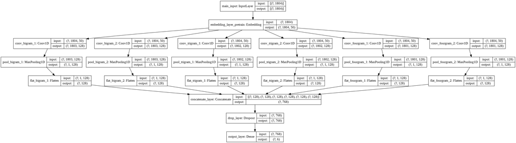

```
**************************************** Start N_gram_CNN Processing ****************************************
Start processing question part
Start numerical output
************************************************** Start train_test_split **************************************************
**************************************** End embedding() with 0.0221 seconds ****************************************

Val_Spearman_Score: 0.088
Val_Spearman_Score: 0.095
Val_Spearman_Score: 0.128
Val_Spearman_Score: 0.145
Val_Spearman_Score: 0.184
Val_Spearman_Score: 0.203
Val_Spearman_Score: 0.227
Val_Spearman_Score: 0.239
Val_Spearman_Score: 0.242
Val_Spearman_Score: 0.253
Val_Spearman_Score: 0.262
Val_Spearman_Score: 0.268
Val_Spearman_Score: 0.255
Val_Spearman_Score: 0.276
Val_Spearman_Score: 0.292
Val_Spearman_Score: 0.282
Val_Spearman_Score: 0.286
Val_Spearman_Score: 0.294
Val_Spearman_Score: 0.286
Val_Spearman_Score: 0.302
Val_Spearman_Score: 0.292
Val_Spearman_Score: 0.294
Val_Spearman_Score: 0.296
Val_Spearman_Score: 0.288
Val_Spearman_Score: 0.295
Val_Spearman_Score: 0.293
Val_Spearman_Score: 0.29
Val_Spearman_Score: 0.298
Val_Spearman_Score: 0.291
Val_Spearman_Score: 0.294
Val_Spearman_Score: 0.29
Val_Spearman_Score: 0.289
Val_Spearman_Score: 0.28
Val_Spearman_Score: 0.294
Val_Spearman_Score: 0.289
Val_Spearman_Score: 0.284
Val_Spearman_Score: 0.282
Val_Spearman_Score: 0.284
Val_Spearman_Score: 0.283
Val_Spearman_Score: 0.295
Val_Spearman_Score: 0.288
Val_Spearman_Score: 0.288
Val_Spearman_Score: 0.293
Val_Spearman_Score: 0.294
Val_Spearman_Score: 0.299
Val_Spearman_Score: 0.292
Val_Spearman_Score: 0.3
Val_Spearman_Score: 0.284
Val_Spearman_Score: 0.288
Val_Spearman_Score: 0.28
**************************************** End N_gram_CNN with 1082.6364 seconds ****************************************
```

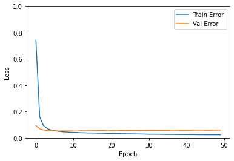

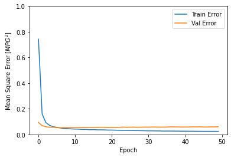

```
over
```

```python
# from class_31_hyperparameters import HyperParameters
# from class_32_import_data import ImportData
# from class_33_clean_data import CleanData
# from class_34_tokenize import TokenizeData
# from class_35_label import LabelProcess
# from class_36_eda import EdaData
# from class_45_embeding import MultiEmbedding
# from class_43_glove import GloveVect
# from class_45_splist_complie import SplitAndCompile
# from class_61_neuralnetwork import BuildModels
# from class_62_cnn import CNNModel
# from class_63_rnn import RNNModel
# from class_69_save import SaveModelHistory
# from class_71_analysis import AnalysisAndPlot
# from class_72_spearmanr import PredictCallback

def main():
  """
  We use this function to call process one by one.
  """

  # ***********************import******************************
  import_class = ImportData()
  # df_train_raw = (6079,41) raw data, which just read from csv file without changing anything
  # X_q_train_df = (6079, 6) only contain ['qa_id', 'question_title', 'question_body', 'category', 'host','question']
  # X_a_train_df = (6079,4) contain ['qa_id', 'answer', 'category', 'host']
  # y_q_train_df = (6079,21) numerical labels
  # y_a_train_df = (6079,9) numerical labels
  (df_train_raw, X_q_train_df, X_a_train_df, y_q_train_df,
    y_a_train_df) = import_class.import_data("/googledrive/MyDrive/Colab_Notebooks/03_data/02_train.csv")
  df_test_raw, X_q_test_df, X_a_test_df, y_q_test_df, y_a_test_df = import_class.import_data("/googledrive/MyDrive/Colab_Notebooks/03_data/03_test.csv")

  # ***********************clean******************************
  clean_class = CleanData()
  q_train_cleaned_df = clean_class.clean_process(X_q_train_df, column_1='question')
  a_train_cleaned_df = clean_class.clean_process(X_a_train_df, column_1='answer')
  q_test_cleaned_df = clean_class.clean_process(X_q_test_df, column_1 ='question')
  a_test_cleaned_df = clean_class.clean_process(X_a_test_df, column_1='answer')

  # ***********************tokenize*****************************
  token_class = TokenizeData()
  # do not use '|', insteand we can use comma to next line and bracket to state they are together
  # input q_train_cleaned_dataframe and output still dataframe with new colunm[padded]
  # question_train part_padded  = (6078, 400)
  (q_train_padded, q_train_cleaned_df, a_train_padded, word_index,
    q_index_word) = token_class.tokenize_data(q_train_cleaned_df, a_train_cleaned_df)


  # ********Using manuually categorical*************
  #***********From this part, we only consider classification version************
  # y_q_train_df
  label_class = LabelProcess(y_q_train_df, y_a_train_df)
  y_q_label_df, y_a_label_df, q_feature_col, a_feature_col = label_class.num_label()
  y_q_classify_list, y_q_classify_dict, y_a_classify_list, y_a_classify_dict = label_class.classify_label()


  # ********************EDA******************************
  # eda_class = EdaData()
  # eda_class.question_plot(y_question_df)
  # eda_class.answer_plot(y_answer_df)
  # q_train_padded have shape (6079,100) can be used in fewer embedding

  # #*********************Embedding****THIS PART ONLY WORD AS API*******************

  glove_class = GloveVect()
  embedding_matrix, embedding_index = glove_class.glove_vect(word_index)
  embed_class = MultiEmbedding()
  #first transform q_train_padded
  # q_glove_output_array, q_glove_embedding_layer= embed_class.glove_embedding(word_index,
  #                                                                            q_train_padded,
  #                                                                            embedding_matrix,
  #                                                                            part = 'q')
  # a_glove_output_array, a_glove_embedding_layer= embed_class.glove_embedding(word_index,
  #                                                                            a_train_padded,
  #                                                                            embedding_matrix,
  #                                                                            part = 'a')
  # q_random_output, q_random_embedding_layer = embed_class.random_embedding(word_index,
  #                                                                          q_train_padded,
  #                                                                           part = 'q')
  # a_random_output, a_random_embedding_layer = embed_class.random_embedding(word_index,
  #                                                                          a_train_padded,
  #                                                                          part = 'a')


  #******************Models*******************************

  model_class = BuildModels()
  compile_class = SplitAndCompile()
  save_class = SaveModelHistory()
  para_class = HyperParameters()
  cnn_class= CNNModel()
  rnn_class = RNNModel()

  # predict_class = PredictCallback()
  #***************Random Embedding Normal Neural Network****************
  # nn_model = model_class.nn_model(word_index, pretrain_matrix=embedding_matrix)
  # history, model = compile_class.compile_fit(nn_model,
  #                                             q_train_padded, a_train_padded, y_q_label_df, y_a_label_df,
  #                                             y_q_classify_list, y_q_classify_dict,
  #                                             y_a_classify_list, y_a_classify_dict,
  #                                             epoch_num=para_class.EPOCH)
  # history_classify_df = save_class.write_csv(history, model)


  # ***************Question Pretrain Gloave Normal CNN Classify*******************
  # cnn_model_1 = cnn_class.normal_cnn(word_index, pretrain_matrix=embedding_matrix)
  # history, model = compile_class.compile_fit(cnn_model_1,
  #                                             q_train_padded, a_train_padded, y_q_label_df, y_a_label_df,
  #                                             y_q_classify_list, y_q_classify_dict,
  #                                             y_a_classify_list, y_a_classify_dict,
  #                                             epoch_num=para_class.EPOCH)
  # history_classify_df = save_class.write_csv(history, model)

  cnn_model_2 = cnn_class.n_gram_cnn(word_index, pretrain_matrix=embedding_matrix)
  history, model = compile_class.compile_fit(cnn_model_2, q_train_padded, a_train_padded, y_q_label_df, y_a_label_df,
                                             y_q_classify_list, y_q_classify_dict,
                                             y_a_classify_list, y_a_classify_dict,
                                             epoch_num=para_class.EPOCH)
  history_classify_df = save_class.write_csv(history, model)

  # rnn_class = RNNModel()
  # lstm_model_1 = rnn_class.lstm(word_index, pretrain_matrix=embedding_matrix)
  # history, model = compile_class.compile_fit(lstm_model_1, q_train_padded, a_train_padded, y_q_label_df, y_a_label_df,
  #                                            y_q_classify_list, y_q_classify_dict,
  #                                            y_a_classify_list, y_a_classify_dict,
  #                                            epoch_num=para_class.EPOCH)
  # history_classify_df = save_class.write_csv(history, model)

  # rnn_class = RNNModel()
  # gru_model_2 = rnn_class.gru(word_index, pretrain_matrix=embedding_matrix)
  # history, model = compile_class.compile_fit(gru_model_2, q_train_padded, a_train_padded, y_q_label_df, y_a_label_df,
  #                                            y_q_classify_list, y_q_classify_dict,
  #                                            y_a_classify_list, y_a_classify_dict,
  #                                            epoch_num=para_class.EPOCH)
  # history_classify_df = save_class.write_csv(history, model)



  #************************test part*****************************
  # 1.tokenize
  # 2.fit model
  # 3.get plot and analysis result
  #*************************END***************************
  plot_class = AnalysisAndPlot(history)
  plot_class.plot_history()


  return (df_train_raw, X_q_train_df, X_a_train_df, y_q_train_df, y_a_train_df, a_train_cleaned_df,
          q_train_padded, q_train_cleaned_df, a_train_padded, word_index, q_index_word,
          y_q_label_df, y_a_label_df, q_feature_col, a_feature_col,
          y_q_classify_list, y_q_classify_dict, y_a_classify_list, y_a_classify_dict,
          history, model)


if __name__=="__main__":
  """
  """
  (df_train_raw, X_q_train_df, X_a_train_df, y_q_train_df, y_a_train_df, a_train_cleaned_df,
    q_train_padded, q_train_cleaned_df, a_train_padded, word_index, q_index_word,
    y_q_label_df, y_a_label_df, q_feature_col, a_feature_col,
    y_q_classify_list, y_q_classify_dict, y_a_classify_list, y_a_classify_dict,
    history, model)= main()
  print("over")
```